# Sustainability Analytics: Project Report Group 2

#### 4.4.2.2 Stationarity with stl

For the decomposition of the water discharge values, we applied as well the STL function.

The most satisfactory results were obtained using an s.window of 24, which captures a seasonal trend with a two-year window, and a t.window of 365 to represent the long-term trend. With these settings, both the ACF and PACF display an abrupt cut at lag 1. The residuals appear random, although regular zero values remain, reflecting the winter season when no water discharge occurs. This effect could not be mitigated by the applied approach.

**Stationarity with stl approach**

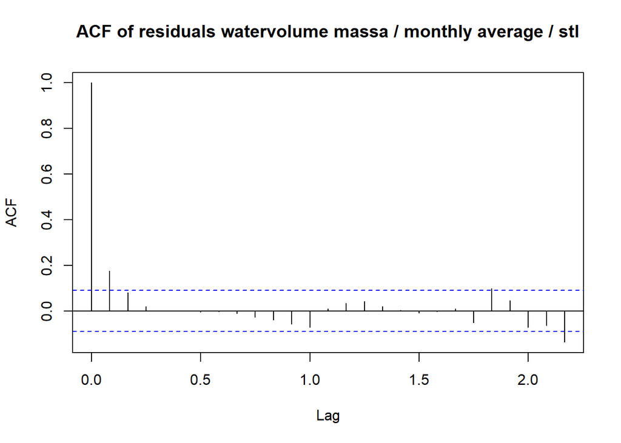

```r
ts_watervolume_monthly_stl <- stl(ts_watervolume_monthly, s.window = 24, t.window=365.2422)
remainder_ts_watervolume_monthly_stl <- ts_watervolume_monthly_stl$time.series[,"remainder"]
acf(remainder_ts_watervolume_monthly_stl, main = "ACF of residuals watervolume massa / monthly average / stl")
```

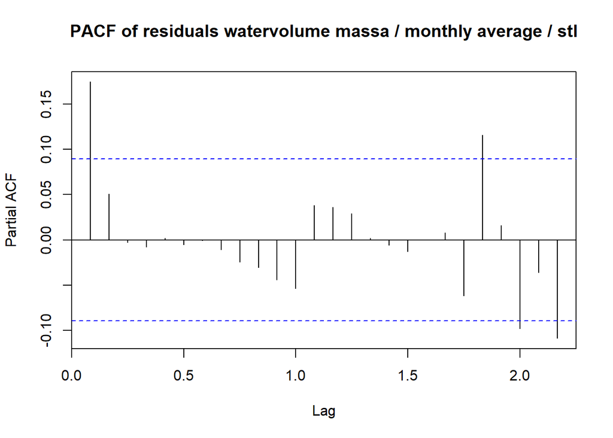

```r
pacf(remainder_ts_watervolume_monthly_stl, main = "PACF of residuals watervolume massa / monthly average / stl")
```

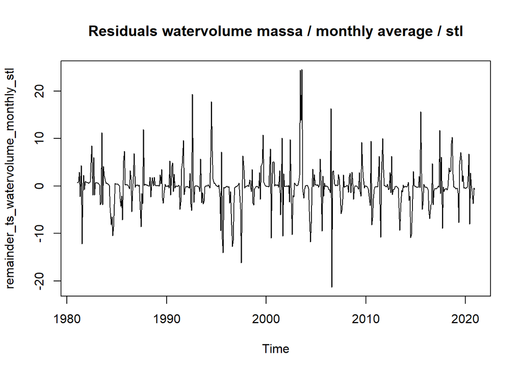

```r
plot(remainder_ts_watervolume_monthly_stl, main = "Residuals watervolume massa / monthly average / stl")
```

```r
adf.test(na.omit(remainder_ts_watervolume_monthly_stl))
```

```
##
##  Augmented Dickey-Fuller Test
##
## data:  na.omit(remainder_ts_watervolume_monthly_stl)
## Dickey-Fuller = -7.4386, Lag order = 7, p-value = 0.01
## alternative hypothesis: stationary
```

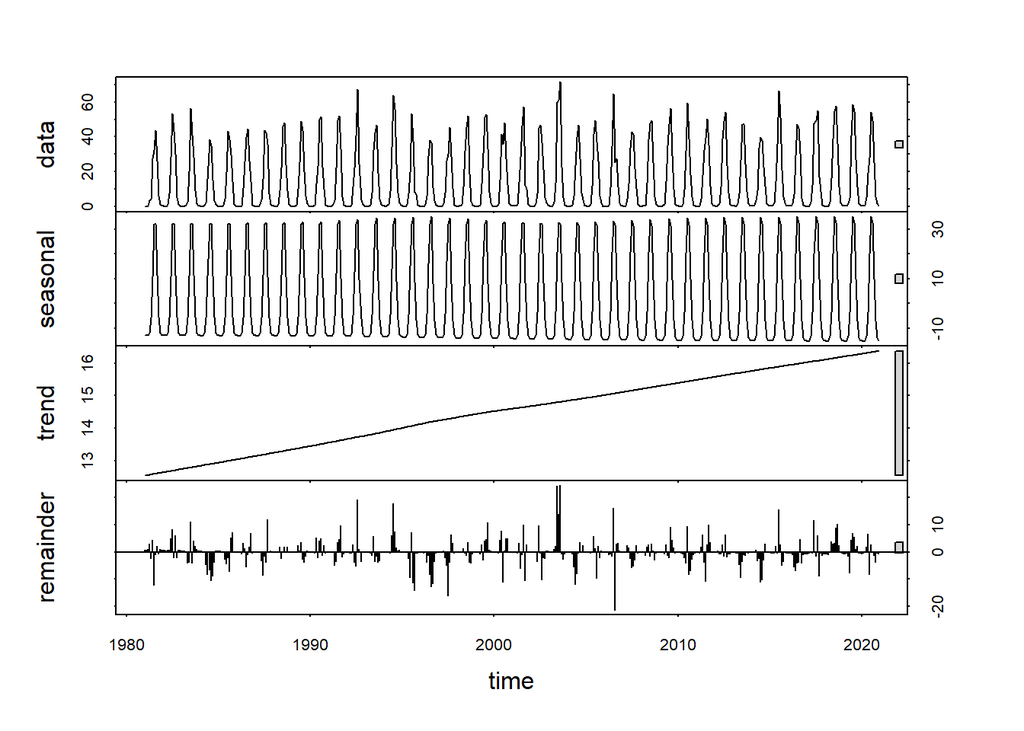

```r
plot(ts_watervolume_monthly_stl)
```

**Creating massa stationary dataframe**

```r
#Creating dataframe of the prepared data
massa_monthly_mean_stl <- data.frame(
  Date      = as.Date(paste(df_massa_monthly$Year, df_massa_monthly$Month, "01", sep = "-")),  # monthly date
  Original  = as.numeric(ts_watervolume_monthly),                 # original data
  Trend     = ts_watervolume_monthly_stl$time.series[,"trend"],         # trend component
  Seasonal  = ts_watervolume_monthly_stl$time.series[,"seasonal"],      # seasonal component
  Remainder = ts_watervolume_monthly_stl$time.series[,"remainder"]      # remainder
)

# # CSV export
# write.csv(
#   massa_monthly_mean_stl,
#   "stationary_monthly_mean_watervolume_massa.csv",
#   row.names = FALSE
# )
#
# # RDS export
saveRDS(massa_monthly_mean_stl, "../data/processed/stationary_monthly_mean_watervolume_massa.rds")
```

## 4.5 Merge Stationary Data

For convenience for further modelling we merged the preprocessed datasets jungfraujoch_temperature, glacier_mass_balance, massa_waterlevel and brig_rain by the date column. Due to different start and end dates we chose to keep the overlapping time period (01/01/1981 to 01/12/2020) in order to get a complete dataset.

**Merge data**

```r
# -----------------------------
# 1) Load data
# -----------------------------
df_jungfrau <- readRDS("../data/processed/jungfraujoch_temperature.rds")
df_glacier <- readRDS("../data/processed/glacier_monthly_processed.rds")
df_waterlevel <- readRDS("../data/processed/waterlevel_det_stoch.rds")
df_waterdischarge <- readRDS("../data/processed/stationary_monthly_mean_watervolume_massa.rds")
df_precipitation <- readRDS("../data/processed/rain_decomposition.rds")

# -----------------------------
# 2) Format Date columns
# -----------------------------
# Jungfrau
n <- nrow(df_jungfrau)
df_jungfrau <- df_jungfrau %>%
  mutate(Date = seq.Date(from = as.Date("1933-01-01"), by = "month", length.out = n))

# Glacier
df_glacier <- df_glacier %>%
  mutate(Date = as.Date(ym(year_month)))

# Waterlevel
month_map <- c(
  "Jan" = 1, "Feb" = 2, "Mär" = 3, "Apr" = 4,
  "Mai" = 5, "Jun" = 6, "Jul" = 7, "Aug" = 8,
  "Sep" = 9, "Okt" = 10, "Nov" = 11, "Dez" = 12
)
df_waterlevel <- df_waterlevel %>%
  mutate(
    Month = sapply(strsplit(year_month, " "), `[`, 1),
    Year = as.numeric(sapply(strsplit(year_month, " "), `[`, 2)),
    Month = month_map[Month],
    Date = as.Date(paste0(Year, "-", Month, "-01"))
  ) %>%
  select(-Month, -Year, -year_month)

# -----------------------------
# 3) Rename columns BEFORE joining
# -----------------------------
df_jungfrau <- df_jungfrau %>%
  rename(
    remainder_jungfrau = remainder,
    trend_jungfrau = trend,
    seasonal_jungfrau = seasonal,
    observed_jungfrau = observed
  )

df_glacier <- df_glacier %>%
  rename(
    remainder_glacier = stochastic,  # rename stochastic -> remainder
    trend_glacier = trend,
    seasonal_glacier = seasonal,
    deterministic_glacier = deterministic,
    mass_balance_glacier = mass_balance_monthly
  )

df_waterlevel <- df_waterlevel %>%
  rename(
    remainder_waterlevel = stochastic,  # rename stochastic -> remainder
    trend_waterlevel = trend,
    seasonal_waterlevel = seasonal,
    deterministic_waterlevel = deterministic,
    waterlevel = waterlevel_m
  )

df_waterdischarge <- df_waterdischarge %>%
  rename(
    remainder_waterdischarge = Remainder,
    trend_waterdischarge = Trend,
    seasonal_waterdischarge = Seasonal,
    waterdischarge = Original
  )

df_precipitation <- df_precipitation %>%
  rename(
    remainder_precipitation = Remainder,
    trend_precipitation = Trend,
    seasonal_precipitation = Seasonal,
    precipitation = Original
  )

# -----------------------------
# 4) Merge datasets by Date
# -----------------------------
df_merged <- df_jungfrau %>%
  full_join(df_glacier, by = "Date") %>%
  full_join(df_waterlevel, by = "Date") %>%
  full_join(df_waterdischarge, by = "Date") %>%
  full_join(df_precipitation, by = "Date") %>%
  arrange(Date)

# -----------------------------
# 5) Select overlapping date range
# -----------------------------
start_overlap <- max(
  min(df_merged$Date[!is.na(df_merged$remainder_jungfrau)]),
  min(df_merged$Date[!is.na(df_merged$remainder_glacier)]),
  min(df_merged$Date[!is.na(df_merged$remainder_waterlevel)]),
  min(df_merged$Date[!is.na(df_merged$remainder_waterdischarge)]),
  min(df_merged$Date[!is.na(df_merged$remainder_precipitation)])
)

end_overlap <- min(
  max(df_merged$Date[!is.na(df_merged$remainder_jungfrau)]),
  max(df_merged$Date[!is.na(df_merged$remainder_glacier)]),
  max(df_merged$Date[!is.na(df_merged$remainder_waterlevel)]),
  max(df_merged$Date[!is.na(df_merged$remainder_waterdischarge)]),
  max(df_merged$Date[!is.na(df_merged$remainder_precipitation)])
)

df_merged_overlap <- df_merged %>%
  drop_na(remainder_jungfrau, remainder_glacier,
          remainder_waterlevel, remainder_waterdischarge,
          remainder_precipitation)

# -----------------------------
# 6) Convert to multivariate ts object
# -----------------------------
df_ts <- df_merged_overlap %>%
  select(
    remainder_jungfrau,
    remainder_glacier,
    remainder_waterlevel,
    remainder_waterdischarge,
    remainder_precipitation
  )

start_year <- year(min(df_merged_overlap$Date))
start_month <- month(min(df_merged_overlap$Date))

ts_multivariate <- ts(df_ts,
                      start = c(start_year, start_month),
                      frequency = 12)

# -----------------------------
# 7) Save processed data
# -----------------------------
write.csv(df_merged_overlap, "../data/processed/df_merged.csv", row.names = FALSE)
saveRDS(df_merged_overlap, "../data/processed/df_merged.rds")
saveRDS(ts_multivariate, "../data/processed/ts_multivariate.rds")
```

# 5 Modelling

## 5.1 Climate-Glacier Model (Annual)

First we examine the relationships between climate variables (mean temperature and total precipitation) with glacier mass balance on a yearly level.

### 5.1.1 Cross-Correlation Analysis (CCF)

We use CCF to identify if there are any lagged effects of climate on glacier melt. This ensures that only variables with meaningful delayed influence will be included as predictors later on.

#### 5.1.1.1 Temperature vs. Glacier

The top left plot shows how changes in the glacier mass-balance depend on the absolute (non-differenced) air temperature. The CCF is significant at lag 1. This indicates that the previous year’s temperature affects the current glacier mass-balance. Since the relationship is negative, higher temperatures are associated with lower glacier mass-balance. Yet since CCF assumes stationarity the result should be interpreted with caution. When using the differenced temperature, the CCF shows no significant lags. This might indicate that year-to-year changes in temperature do not strongly drive glacier mass balance. Therefore for further modelling with ARIMAX temperature lagged once will be included in levels as an external factor.

**CCF Temperature and Glacier mass balance**

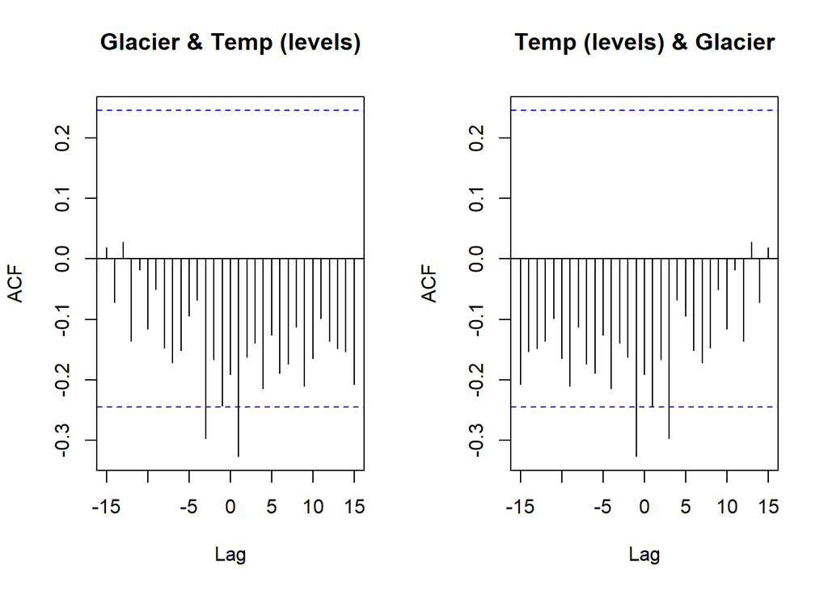

```r
# option 1: temperature in levels
common_start2 <- max(start(ts_jungfraujoch_annual)[1], start(ts_glacier_annually)[1], start(rain_ts_annual)[1])
common_end2   <- min(end(ts_jungfraujoch_annual)[1],   end(ts_glacier_annually)[1],   end(rain_ts_annual)[1])

ts_temp_level_aligned <- window(ts_jungfraujoch_annual, start = common_start2, end = common_end2)
ts_glacier_level_aligned <- window(ts_glacier_annually, start = common_start2, end = common_end2)
ts_rain_level_aligned <- window(rain_ts_annual, start = common_start2, end = common_end2)

par(mfrow = c(1,2))
ccf(ts_glacier_level_aligned, ts_temp_level_aligned, main="Glacier & Temp (levels)")
ccf(ts_temp_level_aligned, ts_glacier_level_aligned, main="Temp (levels) & Glacier")
```

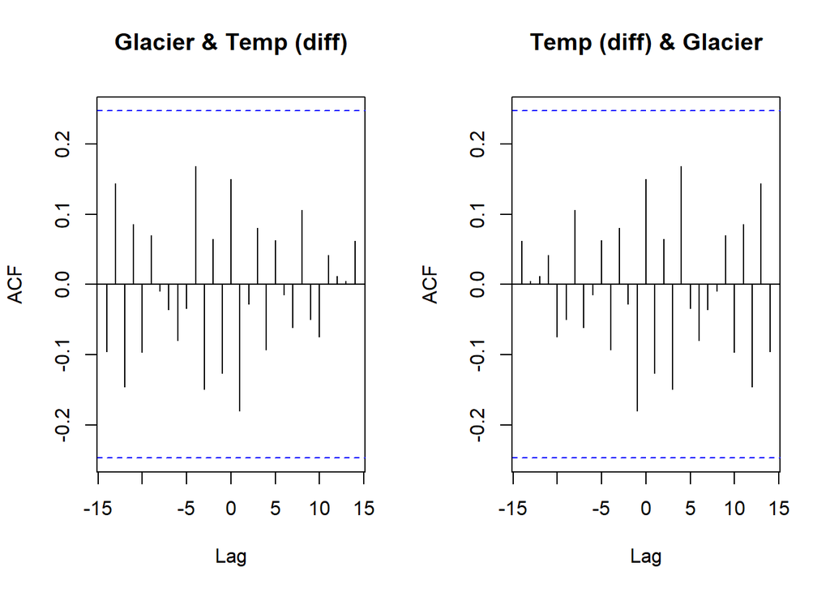

```r
# option 2: differenced temperature

ccf(ts_glacier_level_aligned, diff(ts_temp_level_aligned), main="Glacier & Temp (diff)")
ccf(diff(ts_temp_level_aligned), ts_glacier_level_aligned, main="Temp (diff) & Glacier")
```

We also check the correlation between the temperature lagged once with the glacier mass balance, which is relatively weak (r = -0.19). While temperature has some effect, other factors likely influence the glacier mass balance as well.

**Correlation: Temperature lag 1 with Glacier mass balance**

```r
# Lag temperature by 1 year
temp_lag1 <- stats::lag(ts_temp_level_aligned, -1)
# cor(ts_glacier_level_aligned, ts_temp_level_aligned)
cor(ts_glacier_level_aligned, temp_lag1, use="complete.obs")
```

```
## [1] -0.1910215
```

#### 5.1.1.2 Precipitation vs. Glacier

We now look at the CCF between total annual precipiation and glaicer mass balance. The left plot shows how changes in precipitations might affect glacier mass-balance. The CCF displays no significant lags, indicating no relationship between the two variables. The correlation (r = -0.04) is very weak as well. Since the precipitation was measured in the valley in Brig, it likely doesn’t reflect the snow accumulation on the glacier due to substantial elevation differences. As glaciers respond primarily to seasonal snowfall (in winter), using total annual precipitation may not provide sufficient temporal resolution to capture this effect.

**CCF Precipitation and Glacier mass balance**

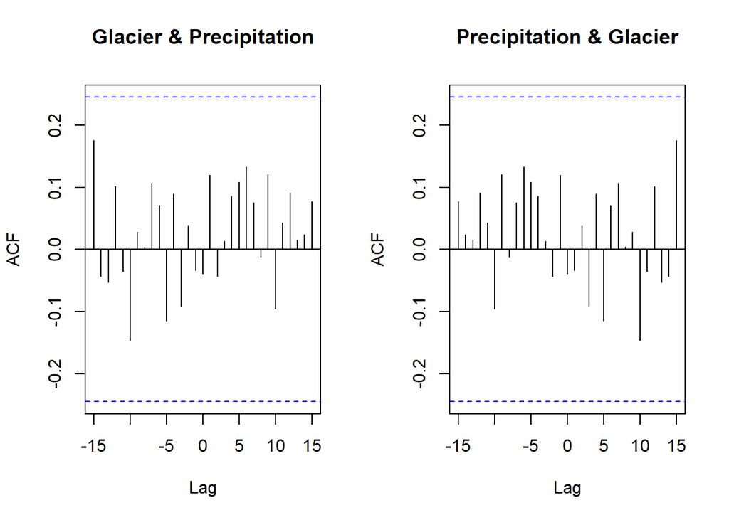

```r
par(mfrow = c(1, 2))
# Precipitation affecting glacier balance
ccf(ts_glacier_level_aligned, ts_rain_level_aligned, main="Glacier & Precipitation")
ccf(ts_rain_level_aligned, ts_glacier_level_aligned, main="Precipitation & Glacier")
```

**Correlation: Precipitation with Glacier mass balance**

```r
# correlation
cor(ts_glacier_level_aligned, ts_rain_level_aligned)
```

```
## [1] -0.03888838
```

### 5.1.2 ARIMAX

We chose to use an ARIMAX model to account for the autocorrelation in the glacier mass balance time series while incorporating temperature as an exogenous variable. This approach allows us to quantify and forecast the influence of climate variables on glacier mass changes over time. Total annual precipitation was not included, as it appeared to explain no variance in glacier mass-balance.

We applied auto.arima() to the glacier mass-balance time series, suggesting an ARIMA(0,0,3) model with non-zero mean.

**Auto Arima**

```r
# determine ARIMA order
fit.auto <- auto.arima(ts_glacier_level_aligned, stationary=TRUE, seasonal=FALSE)
summary(fit.auto)
```

```
## Series: ts_glacier_level_aligned
## ARIMA(0,0,3) with non-zero mean
##
## Coefficients:
##          ma1     ma2     ma3       mean
##       0.0609  0.0749  0.3946  -424.8610
## s.e.  0.1218  0.1249  0.1248   111.7973
##
## sigma^2 = 374549:  log likelihood = -499.68
## AIC=1009.35   AICc=1010.39   BIC=1020.15
##
## Training set error measures:
##                    ME     RMSE      MAE MPE MAPE      MASE         ACF1
## Training set 1.834997 592.5705 462.9329 Inf  Inf 0.7061005 -0.007801287
```

**Auto Arima Residual Check**

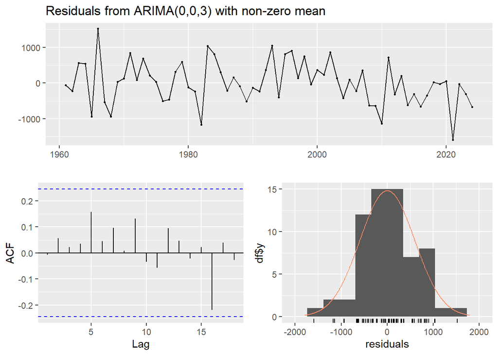

```
##
##  Ljung-Box test
##
## data:  Residuals from ARIMA(0,0,3) with non-zero mean
## Q* = 4.4063, df = 7, p-value = 0.732
##
## Model df: 3.   Total lags used: 10
```

```r
checkresiduals(fit.auto)
```

**Grid search for model order**

```r
# determine ARIMA order
best_aic <- Inf
best_order <- c(0,0,0)

for(p in 0:3){
  for(d in 0:1){
    for(q in 0:3){
      fit <- try(Arima(ts_glacier_aligned, order = c(p,d,q)), silent=TRUE)
      if(!inherits(fit, "try-error")){
        if(AIC(fit) < best_aic){
          best_aic <- AIC(fit)
          best_order <- c(p,d,q)
        }
      }
    }
  }
}
best_order
best_aic
```

Next we included the lagged temperature as an exogeneous variable in the ARIMAX. The model estimates the effect of temperature on glacier mass balance while taking the MA(3) autocorrelation into account.

$$\text{Glacier Balance}_t = -2380.9160
- 270.3527 \cdot \text{Temperature}_{t-1}
+ \varepsilon_t
+ 0.1237\,\varepsilon_{t-1}
- 0.0712\,\varepsilon_{t-2}
+ 0.4184\,\varepsilon_{t-3}$$
The negative coefficient for temperature indicates that higher previous-year temperatures tend to be associated with lower glacier mass balance. The moving average terms account for short-term dependencies in glacier mass balance residuals, meaning past shocks influence the current value.

**ARIMAX Glacier Model with Temperature**

```r
# remove first observation because of lagging
glacier_model_data <- ts_glacier_level_aligned[-1]
temp_lag1_data <- temp_lag1[-length(temp_lag1)]

# ARIMAX
arimax_glacier <- Arima(glacier_model_data,
                        order = c(0,0,3),
                        xreg = temp_lag1_data)
# check model
summary(arimax_glacier)
```

```
## Series: glacier_model_data
## Regression with ARIMA(0,0,3) errors
##
## Coefficients:
##          ma1      ma2     ma3   intercept       xreg
##       0.1237  -0.0712  0.4184  -2380.9160  -270.3527
## s.e.  0.1296   0.1402  0.1137    747.8747   102.0173
##
## sigma^2 = 347278:  log likelihood = -489
## AIC=989.99   AICc=991.49   BIC=1002.85
##
## Training set error measures:
##                     ME     RMSE      MAE MPE MAPE      MASE        ACF1
## Training set -1.381747 565.4347 442.2073 Inf  Inf 0.6668172 -0.03266179
```

For the model fit the residual autocorrelation is low (ACF1 ~ 0.033) and training errors are reasonable (RMSE ~ 565 mm). The visual inspection of the residuals suggests that the model captures temporal structures and the effect of temperature adequately. Plotting the actual observations against the fitted values shows that the ARIMAX captures the main trend in glacier mass balance influenced by previous-year temperature.

**ARIMAX Glacier Model Diagnostics**

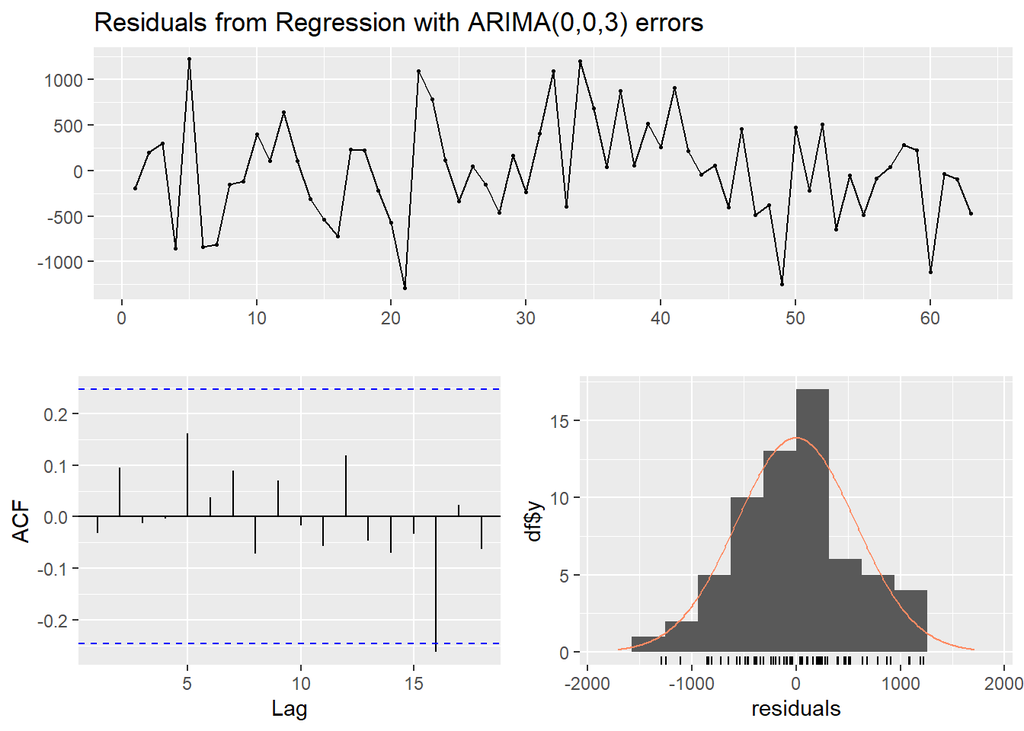

```
##
##  Ljung-Box test
##
## data:  Residuals from Regression with ARIMA(0,0,3) errors
## Q* = 3.9918, df = 7, p-value = 0.7807
##
## Model df: 3.   Total lags used: 10
```

```r
# check residuals
checkresiduals(arimax_glacier)
```

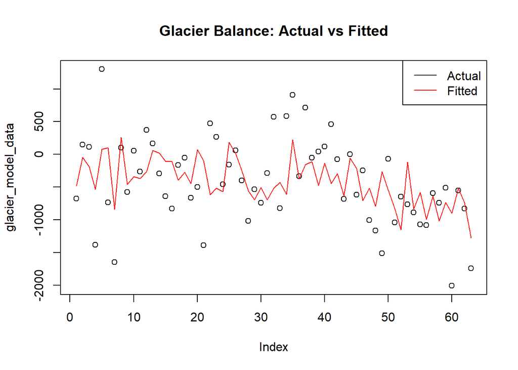

```r
# Plot fitted vs actual
par(mfrow = c(1, 1))
plot(glacier_model_data, main="Glacier Balance: Actual vs Fitted")
lines(fitted(arimax_glacier), col="red")
legend("topright", c("Actual", "Fitted"), col=c("black", "red"), lty=1)
```

### 5.1.3 Climate Scenario-Based Projections

To assess future glacier mass balance of Aletsch Glacier under different climate scenarios we used temperature projections for Jungfraujoch derived from the MeteoSchweiz report “Klimaszenarien Schweiz – eine regionale Übersicht” which is based on the Swiss Climate Scenarios CH2011 ([MeteoSchweiz](https://www.nccs.admin.ch/nccs/de/home/klimawandel-und-auswirkungen/schweizer-klimaszenarien/schweizer-klimaszenarien-im-ueberblick.html#-891137887)).These scenarios provide regional temperature projections for 2060 under different warming assumptions (low, medium and high).

By 2060, glacier mass balance at Jungfraujoch is projected to be negative under all warming scenarios, indicating continued ice loss. Cumulative losses increase with warming: −41,265 mm w.e. for low, −45,641 mm w.e. for medium, and −50,018 mm w.e. for high warming. Even moderate temperature increases (2–3 °C) result in substantial retreat, while higher warming accelerates mass loss. These results highlight the sensitivity of glaciers to temperature changes and the importance of climate mitigation for preserving alpine ice resources.

**Climate Scenario-Based Projections**

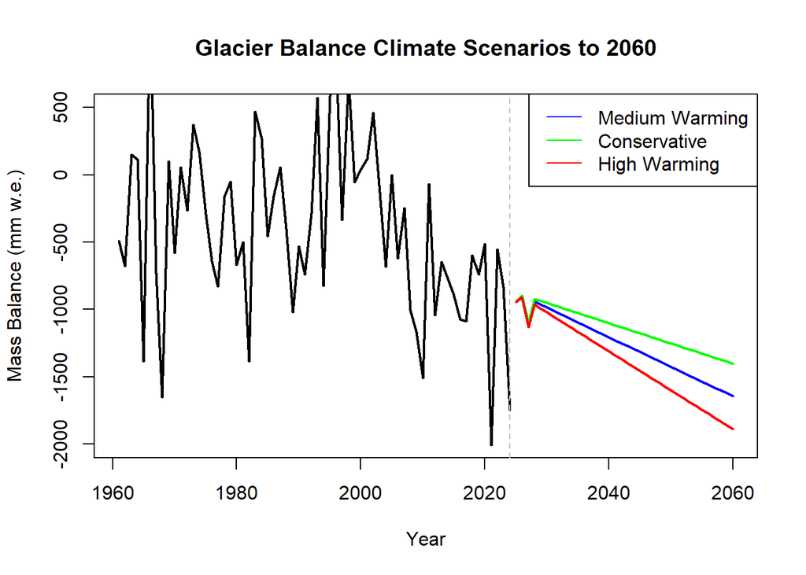

```r
# Historical baselines
jungfraujoch_historical <- data.frame(
  period_1961_1990 = c(winter = -13.6, summer = -1.8),
  period_1981_2010 = c(winter = -12.8, summer = -0.8),
  projection_2060 = c(winter_low = -11.1, winter_high = -9.4,
                     summer_low = 1.5, summer_high = 3.5)
)

# Calculate annual means
annual_1961_1990 <- mean(c(-13.6, -1.8))  # -7.7°C
annual_1981_2010 <- mean(c(-12.8, -0.8))  # -6.8°C
annual_2060_low <- mean(c(-11.1, 1.5))    # -4.8°C
annual_2060_high <- mean(c(-9.4, 3.5))    # -2.95°C

# Current baseline
current_jungfraujoch <- as.numeric(tail(ts_temp_level_aligned, 1))

# Time steps from current to 2060
current_year <- 2024  # end of current ts
target_year <- 2060
years_to_project <- target_year - current_year # 36 years

# Linear warming scenarios
warming_low <- annual_2060_low - annual_1981_2010   # Conservative warming
warming_high <- annual_2060_high - annual_1981_2010 # High warming

# temperature projections
future_years <- 1:years_to_project
temp_scenario_low <- current_jungfraujoch + (warming_low / years_to_project) * future_years
temp_scenario_high <- current_jungfraujoch + (warming_high / years_to_project) * future_years
temp_scenario_medium <- (temp_scenario_low + temp_scenario_high) / 2

# Create lagged temperature matrices for each scenario
scenarios <- list(
  conservative = c(tail(ts_temp_level_aligned, 1), temp_scenario_low[-length(temp_scenario_low)]),
  medium = c(tail(ts_temp_level_aligned, 1), temp_scenario_medium[-length(temp_scenario_medium)]),
  high_warming = c(tail(ts_temp_level_aligned, 1), temp_scenario_high[-length(temp_scenario_high)])
)

# Generate projections
projections <- list()
for(scenario_name in names(scenarios)) {
  projections[[scenario_name]] <- forecast(arimax_glacier,
                                          h = years_to_project,
                                          xreg = scenarios[[scenario_name]])
}

# Get the actual years from your historical data
hist_years <- as.numeric(time(ts_glacier_level_aligned))
forecast_years <- seq(max(hist_years) + 1, target_year, by = 1)

# Create extended time series
all_years <- c(hist_years, forecast_years)
hist_data <- as.numeric(ts_glacier_level_aligned)

# Custom plot with proper year labels
plot(all_years[1:length(hist_data)], hist_data,
     type = "l", xlim = c(min(all_years), max(all_years)),
     ylim = c(-2000, 500), col = "black", lwd = 2,
     main = "Glacier Balance Climate Scenarios to 2060",
     xlab = "Year", ylab = "Mass Balance (mm w.e.)")

# Add forecast scenarios
lines(forecast_years, projections$medium$mean, col = "blue", lwd = 2)
lines(forecast_years, projections$conservative$mean, col = "green", lwd = 2)
lines(forecast_years, projections$high_warming$mean, col = "red", lwd = 2)

# Add vertical line at forecast start
abline(v = max(hist_years), lty = 2, col = "gray")

legend("topright", c("Medium Warming", "Conservative", "High Warming"),
       col = c("blue", "green", "red"), lty = 1)
```

```r
# Summary of projections
final_projections <- data.frame(
  Scenario = c("Low Warming", "Medium Warming", "High Warming"),
  Temp_Change_by_2060 = c(round(warming_low, 1),
                          round(mean(c(warming_low, warming_high)), 1),
                          round(warming_high, 1)),
  Final_Balance_2060 = round(c(tail(projections$conservative$mean, 1),
                              tail(projections$medium$mean, 1),
                              tail(projections$high_warming$mean, 1)), 0),
  Cumulative_Loss = round(c(sum(projections$conservative$mean[projections$conservative$mean < 0]),
                           sum(projections$medium$mean[projections$medium$mean < 0]),
                           sum(projections$high_warming$mean[projections$high_warming$mean < 0])), 0)
)
print(final_projections)
```

```
##         Scenario Temp_Change_by_2060 Final_Balance_2060 Cumulative_Loss
## 1    Low Warming                 2.0              -1402          -41265
## 2 Medium Warming                 2.9              -1645          -45641
## 3   High Warming                 3.9              -1888          -50018
```

The 95% confidence intervals (CIs) around the glacier mass balance projections represent statistical uncertainty in the ARIMAX model estimates. They account for variability in the model parameters and residuals, providing a range in which the true glacier mass balance is likely to fall. In our case the CIs are quite wide for all three scenarios, therefore conclusions should only be drawn with caution.

**Confidence Intervalls**

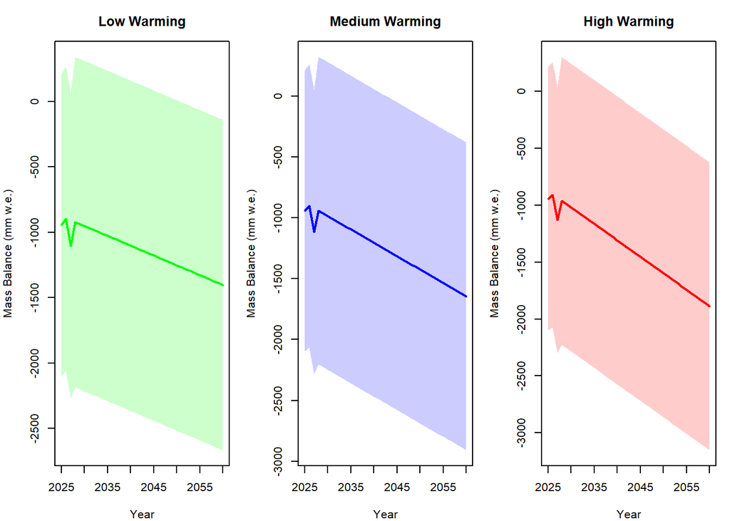

```r
# Years for the forecast
forecast_years <- seq(max(as.numeric(time(ts_glacier_level_aligned))) + 1, 2060, by = 1)

# Set up 1 row x 3 columns for the panels
par(mfrow = c(1, 3), mar = c(4, 4, 3, 1))  # adjust margins

# Function to plot a scenario with CI
plot_scenario_CI <- function(proj, scenario_name, color) {
  plot(forecast_years, proj$mean, type = "l", col = color, lwd = 2,
       ylim = range(c(proj$lower[,2], proj$upper[,2])),
       main = scenario_name,
       xlab = "Year", ylab = "Mass Balance (mm w.e.)")

  # Add 95% CI as shaded polygon
  polygon(c(forecast_years, rev(forecast_years)),
          c(proj$lower[,2], rev(proj$upper[,2])),
          col = adjustcolor(color, alpha.f = 0.2),
          border = NA)

  # Add mean line on top
  lines(forecast_years, proj$mean, col = color, lwd = 2)
}

# Plot each scenario in its panel
plot_scenario_CI(projections$conservative, "Low Warming", "green")
plot_scenario_CI(projections$medium, "Medium Warming", "blue")
plot_scenario_CI(projections$high_warming, "High Warming", "red")
```

```r
# Reset plotting layout to default
par(mfrow = c(1, 1))
```

## 5.2 Climate-River Model (Monthly)

We now examine how climate-driven changes in glacier mass-balance affect the water level and discharge of Massa.

### 5.2.1 Cross-Correlation Analysis (CCF)

To investigate potential linear relationships between the different time series, we use the cross-correlation function (ccf). For this we only need the stationary remainder components of each time series, since we want to avoid spurious correlations caused by trends and seasonal components.

#### 5.2.1.1 Temperature vs. Glacier

When looking at the output of the cross-correlation function between Jungfraujoch temperature and glacier mass balance the correlations are very weak (|r| < 0.3), indicating little to no relationship between the two variables. At a first glance this result surprised us. Yet considering that the glacier mass balance data had been transformed to show change from year to year (by differencing with a lag of 12), this finding made sense. Glaciers react slowly and mainly to long-term seasonal and yearly patterns, not to short monthly changes. Because the two datasets were on different time scales (monthly temperature and annually glacier mass balance), it was not possible to detect a direct correlation between them.

**CCF Jungfraujoch Temperature & Glacier Mass Balance**

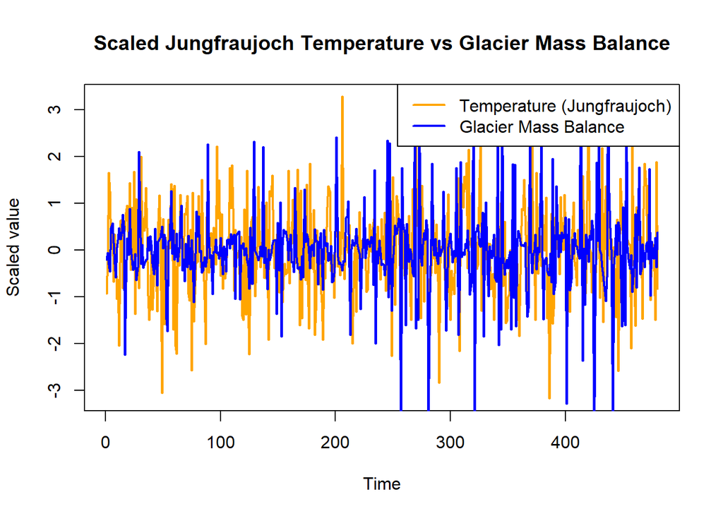

```r
# convert to numeric vectors
jungfrau <- as.numeric(ts_multivariate[, "remainder_jungfrau"])
glacier  <- as.numeric(ts_multivariate[, "remainder_glacier"])

# Plot scaled series
plot(scale(jungfrau), type = "l", col = "orange", lwd = 2,
     ylab = "Scaled value", xlab = "Time",
     main = "Scaled Jungfraujoch Temperature vs Glacier Mass Balance")
lines(scale(glacier), col = "blue", lwd = 2)
legend("topright", legend = c("Temperature (Jungfraujoch)", "Glacier Mass Balance"),
       col = c("orange", "blue"), lty = 1, lwd = 2)
```

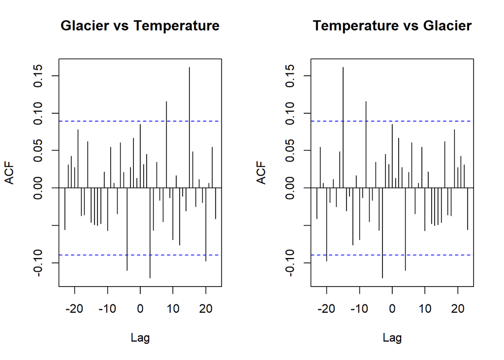

```r
par(mfrow = c(1, 2))
# CCF: Temperature leads Glacier
ccf(glacier, jungfrau, # temperature leads
    main = "Glacier vs Temperature")
# CCF: Glacier leads Temperatues
ccf(jungfrau, glacier, # glacier leads
    main = "Temperature vs Glacier")
```

#### 5.2.1.2 Glacier vs. Massa River

The same argumentation as above applies to the cross-correlation function between glacier mass balance and the waterlevel and waterdischarge of the river Massa.

**CCF Glacier Mass Balance & Massa Waterlevel**

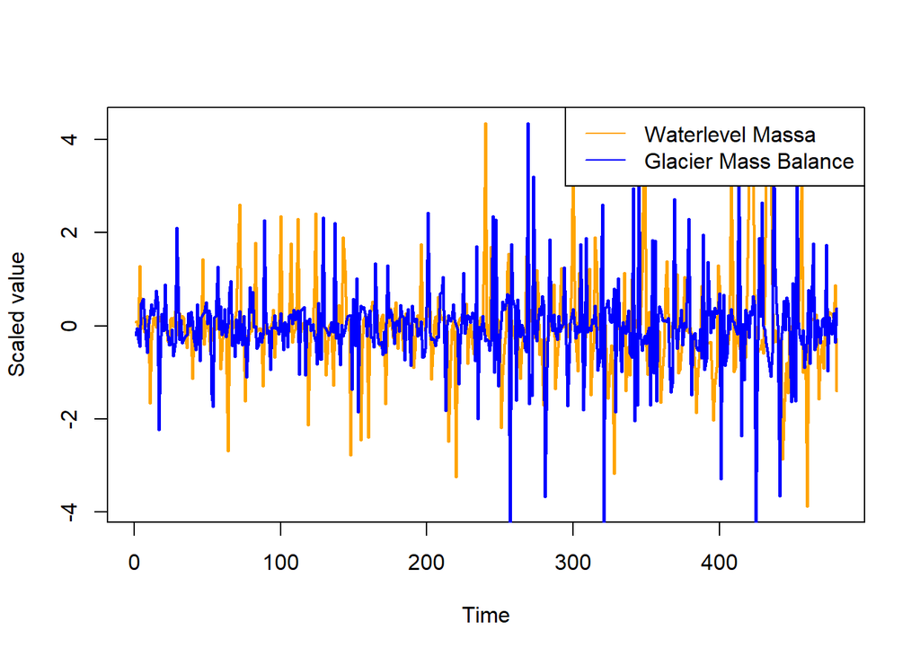

```r
# Scale the two series and convert to numeric vectors
waterlevel <- as.numeric(ts_multivariate[, "remainder_waterlevel"])
glacier  <- as.numeric(ts_multivariate[, "remainder_glacier"])

# Plot scaled series
plot(scale(waterlevel), type="l", col="orange", lwd=2,
     ylab="Scaled value", xlab="Time")
lines(scale(glacier), col="blue", lwd=2)
legend("topright", legend=c("Waterlevel Massa", "Glacier Mass Balance"),
       col=c("orange","blue"), lty=1)
```

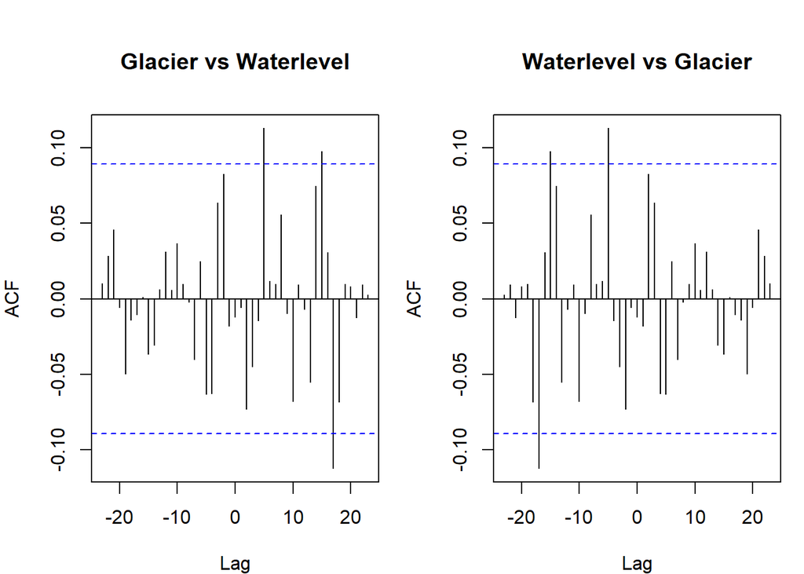

```r
# Set 1x2 layout and increase top margin
par(mfrow = c(1, 2), mar = c(4, 4, 5, 1)) # bottom, left, top, right
# CCF: Waterlevel leads Glacier
ccf(glacier, waterlevel, # waterlevel leads
    main = "Glacier vs Waterlevel")
# CCF: Glacier leads Waterlevel
ccf(waterlevel, glacier, # glacier leads
    main = "Waterlevel vs Glacier")
```

```r
# Reset plotting parameters
par(mfrow = c(1, 1), mar = c(5, 4, 4, 2) + 0.1)
```

**CCF Glacier Mass Balance & Massa Waterdischarge**

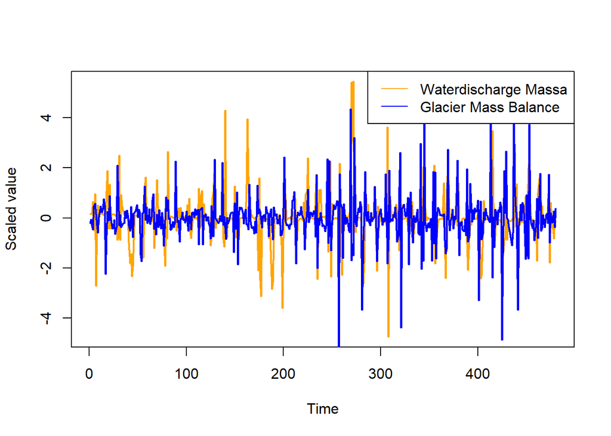

```r
# Scale the two series and convert to numeric vectors
waterdischarge <- as.numeric(ts_multivariate[, "remainder_waterdischarge"])
glacier <- as.numeric(ts_multivariate[, "remainder_glacier"])

# Plot scaled series
plot(scale(waterdischarge), type="l", col="orange", lwd=2,
     ylab="Scaled value", xlab="Time")
lines(scale(glacier), col="blue", lwd=2)
legend("topright", legend=c("Waterdischarge Massa", "Glacier Mass Balance"),
       col=c("orange","blue"), lty=1)
```

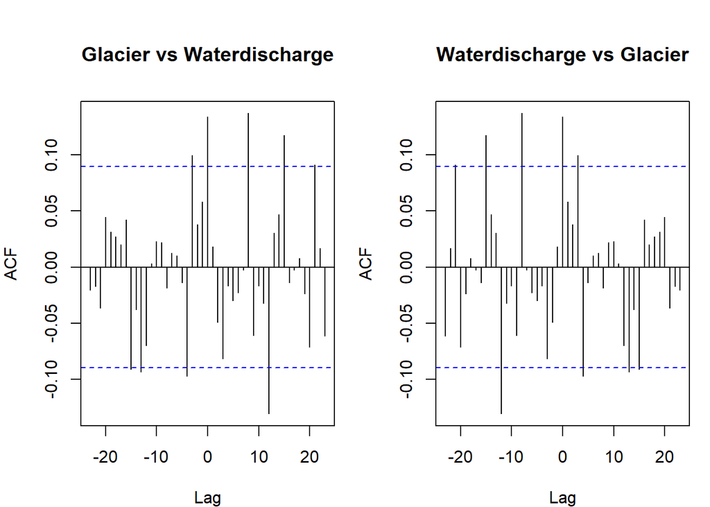

```r
# Set 1x2 layout and increase top margin
par(mfrow = c(1, 2), mar = c(4, 4, 5, 1)) # bottom, left, top, right
# CCF: Waterlevel leads Glacier
ccf(glacier, waterdischarge, # waterdischarge leads
    main = "Glacier vs Waterdischarge")
# CCF: Glacier leads Waterlevel
ccf(waterdischarge, glacier, # glacier leads
    main = "Waterdischarge vs Glacier")
```

```r
# Reset plotting parameters
par(mfrow = c(1, 1), mar = c(5, 4, 4, 2) + 0.1)
```

#### 5.2.1.3 Temperature vs. Massa River

For the cross-correlation function between the Jungfraujoch temperature and the waterlevels of Massa we can observe that temperature is leading with a weak yet significant positive correlations at lag 0.This indicates that higher temperatures are associated with slightly higher water levels in the same month, although the effect is small.

**CCF Jungfraujoch Temperature & Massa Waterlevel**

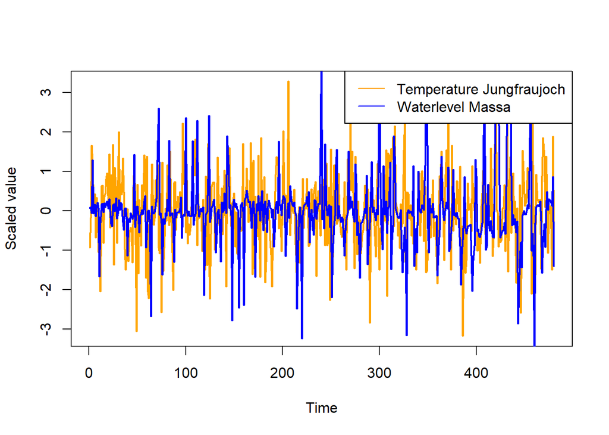

```r
# Scale the two series and convert to numeric vectors
jungfrau <- as.numeric(ts_multivariate[, "remainder_jungfrau"])
waterlevel  <- as.numeric(ts_multivariate[, "remainder_waterlevel"])

# Plot scaled series
plot(scale(jungfrau), type="l", col="orange", lwd=2,
     ylab="Scaled value", xlab="Time")
lines(scale(waterlevel), col="blue", lwd=2)
legend("topright", legend=c("Temperature Jungfraujoch", "Waterlevel Massa"),
       col=c("orange","blue"), lty=1)
```

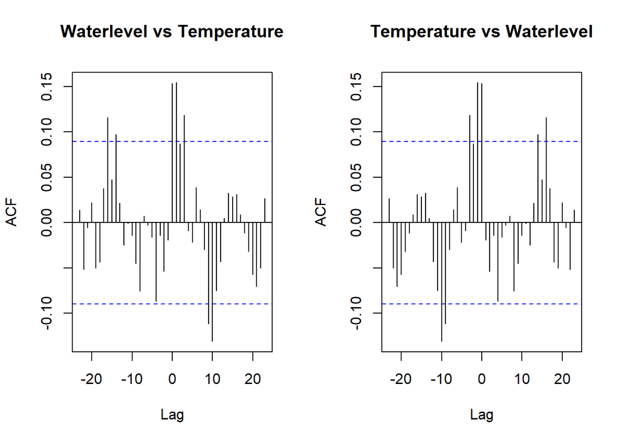

```r
# Set 1x2 layout and increase top margin
par(mfrow = c(1, 2))
# CCF: Temperature leads Waterlevel
ccf(waterlevel, jungfrau,
    main = "Waterlevel vs Temperature")
# CCF: Glacier leads Temperatues
ccf(jungfrau, waterlevel,
    main = "Temperature vs Waterlevel")
```

When considering water discharge instead of water level, the correlation at lag 0 is stronger. This indicates that the monthly water discharge of Massa responds directly and quickly to temperature changes. Higher temperatures lead to increased discharge, reflecting the immediate hydrological response from snow and glacier melt, while lower temperatures correspond to reduced discharge due to reduced melt and freezing.

**CCF Jungfraujoch Temperature & Massa Waterdischarge**

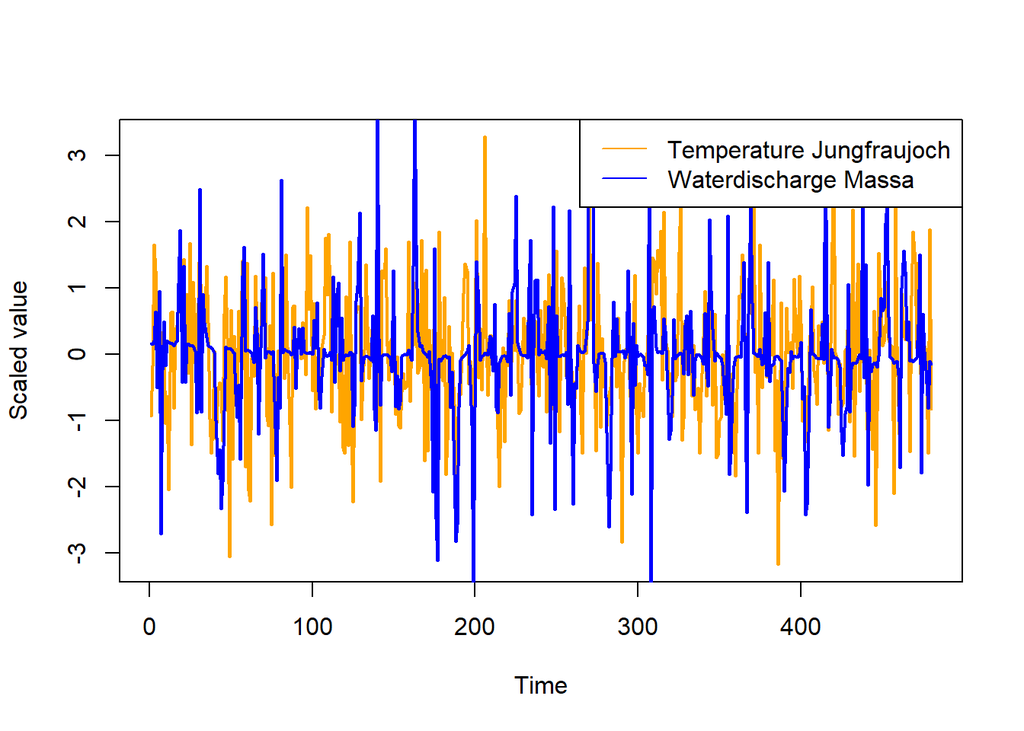

```r
# Scale the two series and convert to numeric vectors
jungfrau <- as.numeric(ts_multivariate[, "remainder_jungfrau"])
waterdischarge  <- as.numeric(ts_multivariate[, "remainder_waterdischarge"])

# Plot scaled series
plot(scale(jungfrau), type="l", col="orange", lwd=2,
     ylab="Scaled value", xlab="Time")
lines(scale(waterdischarge), col="blue", lwd=2)
legend("topright", legend=c("Temperature Jungfraujoch", "Waterdischarge Massa"),
       col=c("orange","blue"), lty=1)
```

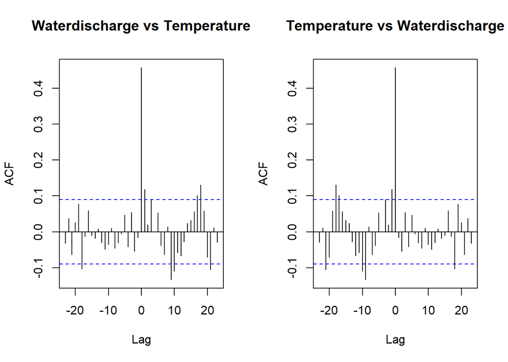

```r
# Set 1x2 layout and increase top margin
par(mfrow = c(1, 2))
# CCF: Temperature leads Waterdischarge
ccf(waterdischarge, jungfrau,
    main = "Waterdischarge vs Temperature")
# CCF: Glacier leads Temperatues
ccf(jungfrau, waterdischarge,
    main = "Temperature vs Waterdischarge")
```

#### 5.2.1.4 Precipitation vs. Massa River

**CCF Precipitation Brig & Massa Waterlevel**

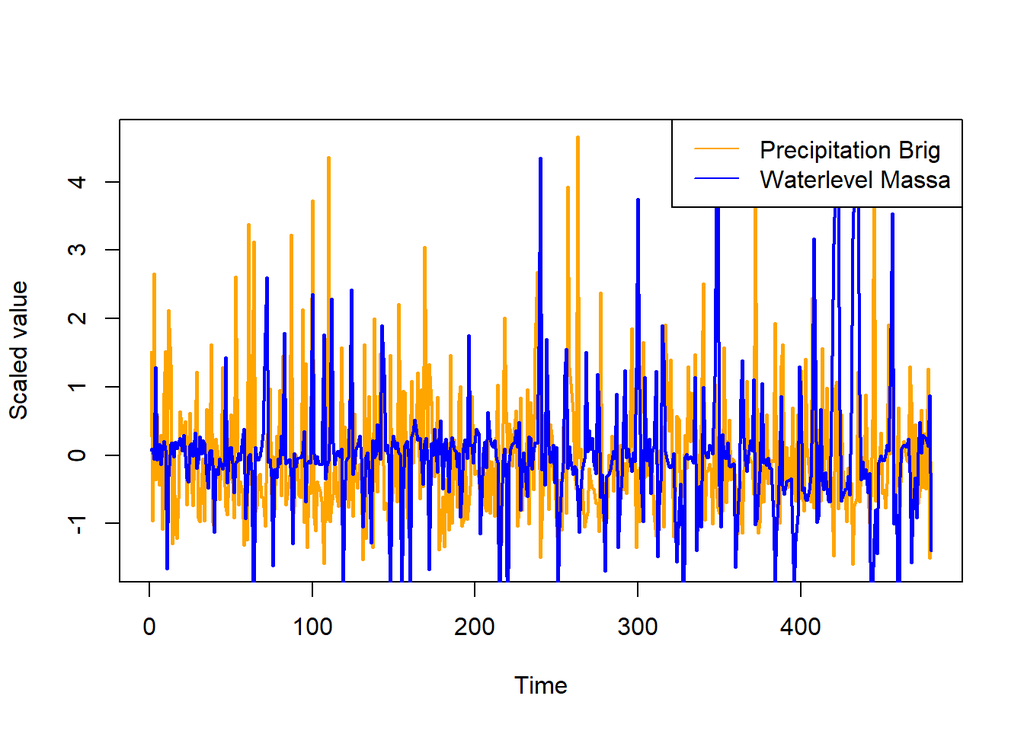

```r
# Scale the two series and convert to numeric vectors
precipitation <- as.numeric(ts_multivariate[, "remainder_precipitation"])
waterlevel  <- as.numeric(ts_multivariate[, "remainder_waterlevel"])

# Plot scaled series
plot(scale(precipitation), type="l", col="orange", lwd=2,
     ylab="Scaled value", xlab="Time")
lines(scale(waterlevel), col="blue", lwd=2)
legend("topright", legend=c("Precipitation Brig", "Waterlevel Massa"),
       col=c("orange","blue"), lty=1)
```

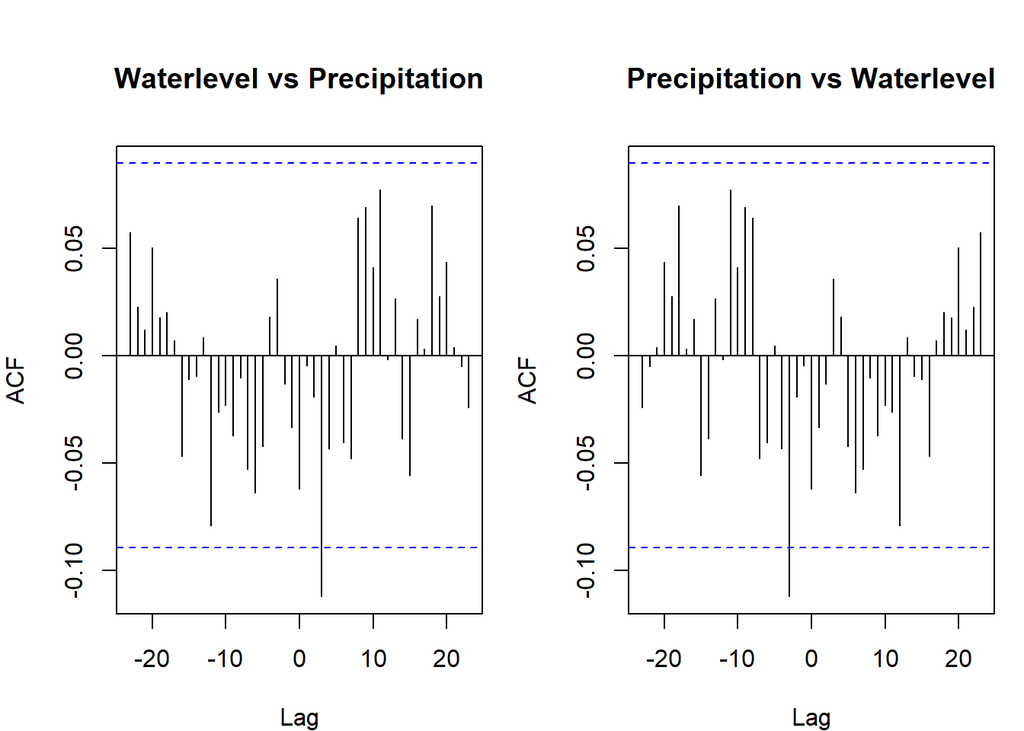

```r
# Set 1x2 layout and increase top margin
par(mfrow = c(1, 2), mar = c(4, 4, 5, 1)) # bottom, left, top, right
# CCF: Precipitation leads Waterlevel
ccf(waterlevel, precipitation,
    main = "Waterlevel vs Precipitation")
# CCF: Waterlevel leads Precipitation
ccf(precipitation, waterlevel,
    main = "Precipitation vs Waterlevel")
```

```r
# Reset plotting parameters
par(mfrow = c(1, 1), mar = c(5, 4, 4, 2) + 0.1)
```

**CCF Precipitation Brig & Massa Waterdischarge**

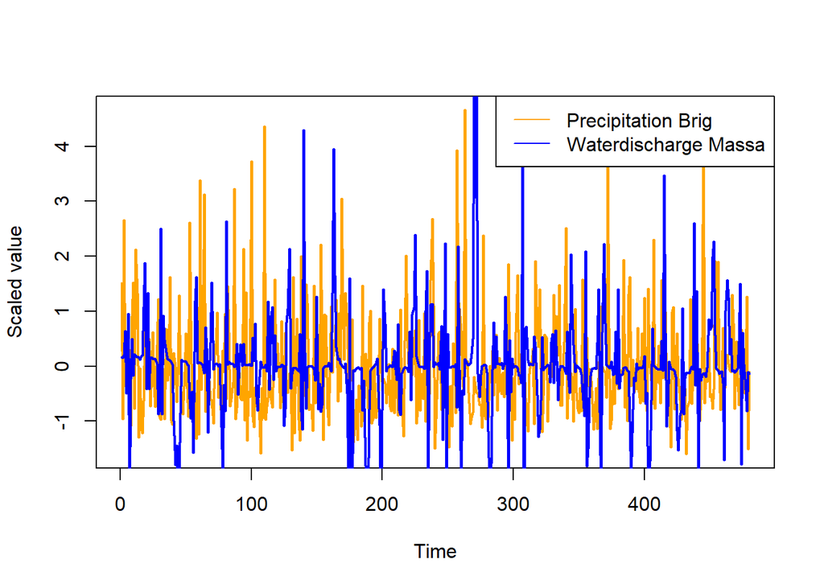

```r
# Scale the two series and convert to numeric vectors
precipitation <- as.numeric(ts_multivariate[, "remainder_precipitation"])
waterdischarge  <- as.numeric(ts_multivariate[, "remainder_waterdischarge"])

# Plot scaled series
plot(scale(precipitation), type="l", col="orange", lwd=2,
     ylab="Scaled value", xlab="Time")
lines(scale(waterdischarge), col="blue", lwd=2)
legend("topright", legend=c("Precipitation Brig", "Waterdischarge Massa"),
       col=c("orange","blue"), lty=1)
```

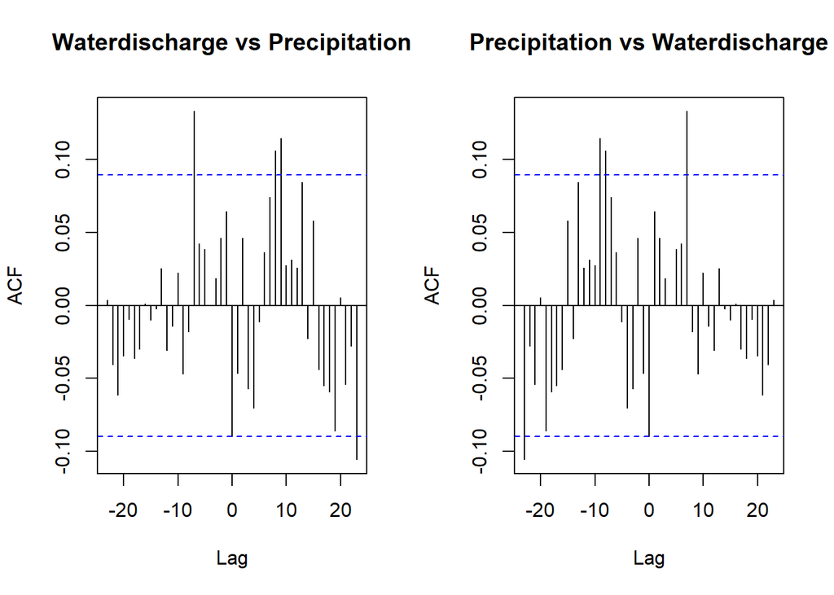

```r
# Set 1x2 layout and increase top margin
par(mfrow = c(1, 2))
# CCF: Precipitation leads Waterdischarge
ccf(waterdischarge, precipitation,
    main = "Waterdischarge vs Precipitation")
# CCF: Waterdischarge leads Precipitation
ccf(precipitation, waterdischarge,
    main = "Precipitation vs Waterdischarge")
```

### 5.2.2 ARIMAX

For the ARIMAX we decided to focus on water discharge rather than water level, since it is more directly influenced by climate variables.

**Auto Arima**

```r
# auto arima for water discharge
fit.auto <- auto.arima(waterdischarge, stationary = TRUE, seasonal = TRUE)
summary(fit.auto)
```

```
## Series: waterdischarge
## ARIMA(1,0,0) with zero mean
##
## Coefficients:
##          ar1
##       0.1740
## s.e.  0.0449
##
## sigma^2 = 19.64:  log likelihood = -1395.2
## AIC=2794.41   AICc=2794.43   BIC=2802.75
##
## Training set error measures:
##                       ME     RMSE      MAE      MPE     MAPE     MASE
## Training set 0.002657597 4.426908 2.486354 12.00747 194.4844 0.753346
##                      ACF1
## Training set -0.008466686
```

**Auto Arima Resiudal Check**

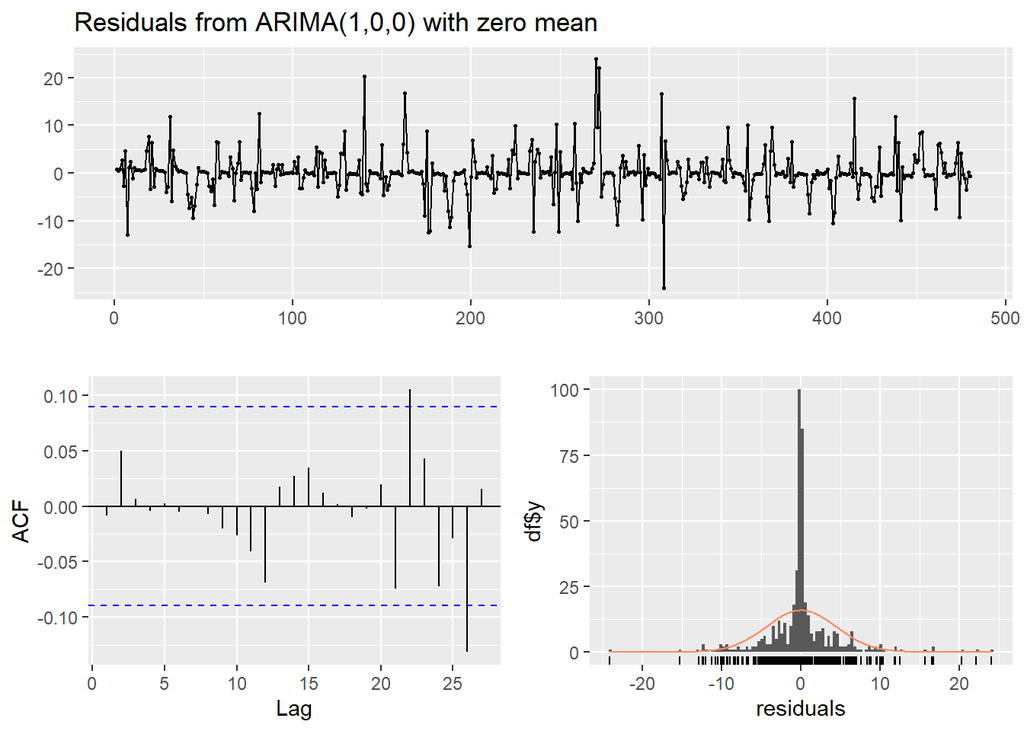

```
##
##  Ljung-Box test
##
## data:  Residuals from ARIMA(1,0,0) with zero mean
## Q* = 1.8536, df = 9, p-value = 0.9936
##
## Model df: 1.   Total lags used: 10
```

```r
checkresiduals(fit.auto)
```

$$\text{Water Discharge}_t = −0.0367
+ 1.1547 \cdot \text{Temperature}_{t}
+ 0.003 \cdot \text{Precipitation}_{t-6}
+ \varepsilon_t
+ 0.1433\,\varepsilon_{t-1}$$

**ARIMAX**

```r
# align ts and lag precipitation
# Lag precipitation by 6 (current month is lag 0)
precip_lag6 <- dplyr::lag(precipitation, 6)  # negative lag shifts forward

# Align series and remove NAs caused by lag
complete_idx <- complete.cases(waterdischarge, jungfrau, precip_lag6)
discharge_clean <- waterdischarge[complete_idx]
temp_clean <- jungfrau[complete_idx]          # lag 0, current month
precip_clean <- precip_lag6[complete_idx]

# -----------------------------
# 3) Build ARIMAX model with temperature lag 0 and precipitation lag 6
# -----------------------------
arimax_monthly <- Arima(discharge_clean,
                        order = c(0,0,1),      # From auto.arima
                        xreg = cbind(temp_clean, precip_clean),
                        include.constant = TRUE)
rmse_val <- accuracy(arimax_monthly)[1,"RMSE"] # For dynamic text
summary(arimax_monthly)
```

```
## Series: discharge_clean
## Regression with ARIMA(0,0,1) errors
##
## Coefficients:
##          ma1  intercept  temp_clean  precip_clean
##       0.1433    -0.0367      1.1547        0.0030
## s.e.  0.0406     0.2080      0.1046        0.0037
##
## sigma^2 = 15.83:  log likelihood = -1325.19
## AIC=2660.37   AICc=2660.5   BIC=2681.18
##
## Training set error measures:
##                     ME     RMSE      MAE       MPE     MAPE      MASE      ACF1
## Training set 0.0030808 3.962167 2.745108 -3537.856 4986.842 0.8374667 0.0172184
```

**ARIMAX model fit**

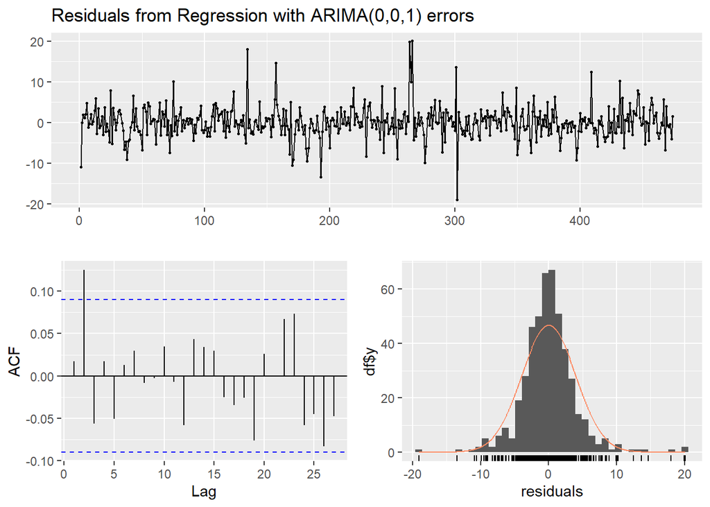

```
##
##  Ljung-Box test
##
## data:  Residuals from Regression with ARIMA(0,0,1) errors
## Q* = 11.617, df = 9, p-value = 0.2358
##
## Model df: 1.   Total lags used: 10
```

```r
# check residuals
checkresiduals(arimax_monthly)
```

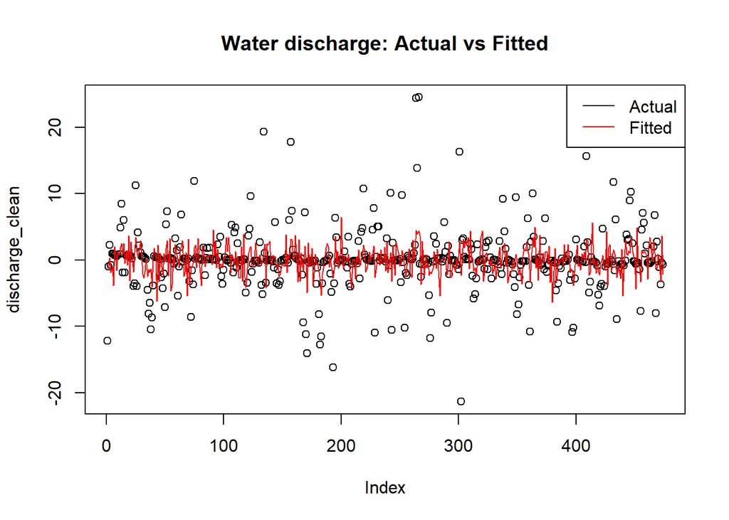

```r
# Plot fitted vs actual
par(mfrow = c(1, 1))
plot(discharge_clean, main="Water discharge: Actual vs Fitted")
lines(fitted(arimax_monthly), col="red")
legend("topright", c("Actual", "Fitted"), col=c("black", "red"), lty=1)
```

When using the ARIMAX to forecast the next 12 months we see a continuation of the main trend.

**ARIMAX forecast**

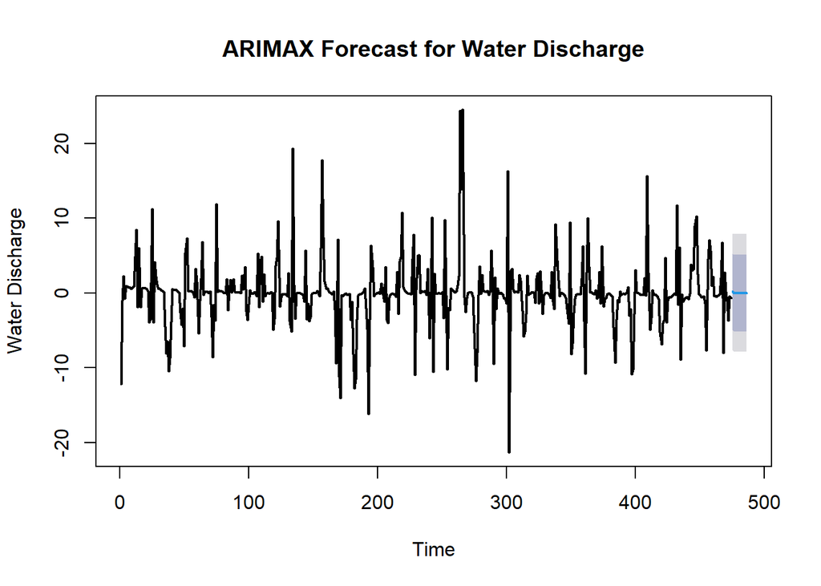

```r
# forecast next 12 months
horizon <- 12
future_temp <- rep(mean(temp_clean), horizon)
future_precip <- rep(mean(precip_clean), horizon)

forecast_values <- forecast(arimax_monthly,
                            h = horizon,
                            xreg = cbind(future_temp, future_precip))

# Plot forecast
plot(forecast_values, main = "ARIMAX Forecast for Water Discharge",
     ylab = "Water Discharge", xlab = "Time")
lines(discharge_clean, col = "black", lwd = 2)
```

Since the ARIMAX is not suitable to assess the risk and frequency of rare high-discharge events, we applied extreme value theory (EVT) in our further analysis.

## 5.3 Extreme Value Theory (EVT)

For the EVT analysis, we focus primarily on the Massa River, while the identical data preparation and visualization steps for the Rhone River are provided in the appendix. As the Rhone is not the core subject of this project, its results are not discussed in detail in the main body of the report.

### 5.3.1 River Massa

In this section, we take a closer look at the water discharge of the Massa River, measured in cubic meters per second (m³/s), as it provides a reliable indication of the river’s flow volume.

By comparing the plots, it becomes apparent that the BAG dataset contains many observations exceeding 100 m³/s, whereas our dataset does not surpass this threshold, despite overlapping observation periods. A key difference is that the BAG report is based on daily maximum values, whereas our analysis uses daily mean values.

**Daily maximum water discharge plot of river Massa (Screenshot out of BAG report)**

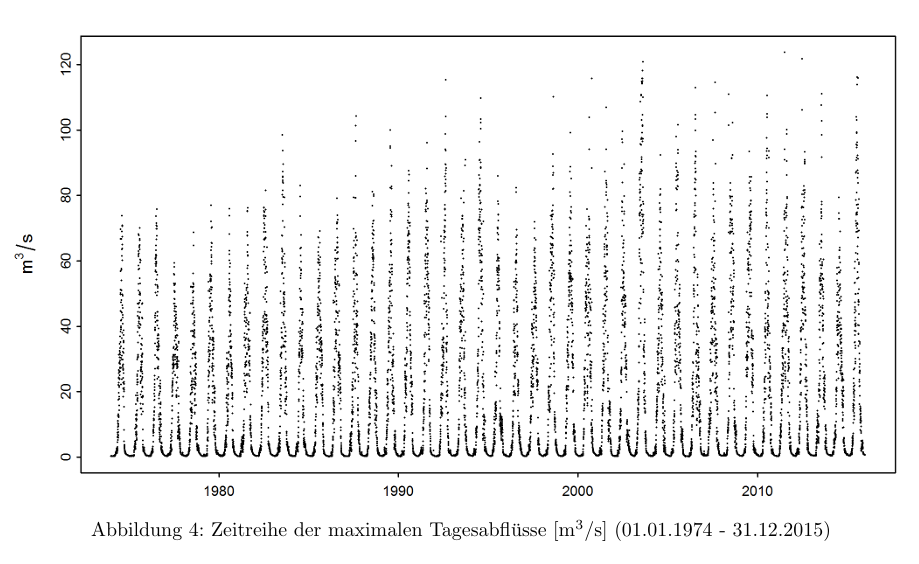

```r
knitr::include_graphics('../data/raw/BAG_Massa_Discharge_Plot.png')
```

**Daily mean water discharge plot of river Massa**

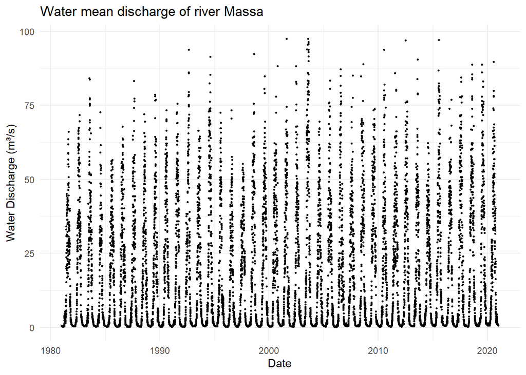

```r
ggplot(df_massa_prep, aes(x=df_massa_prep$Date, y=df_massa_prep$Watervolume)) +
  geom_point(size = 0.5) +
  labs(
    title = "Water mean discharge of river Massa",
    x = "Date",
    y = "Water Discharge (m³/s)"
  ) +
  theme_minimal()
```

When cross-checking our data with the [Massa – Blatten bei Naters](https://www.hydrodaten.admin.ch/en/seen-und-fluesse/stations/2161#waterlevel-annual) records, which also provide daily mean values, we find identical results, confirming the accuracy and reliability of our dataset.

Due to the differences in data sources and measurement approaches, it is likely that our EVT results will differ from those presented in the BAG report. Nevertheless, the BAG report remains a valuable reference, allowing us to assess whether our findings exhibit similar patterns.

#### 5.3.1.1 Histogram of water discharge of river Massa

The histogram exhibits a pronounced right-skewed distribution, which at first glance might seem counterintuitive. This can be attributed to the hydrological regime of the Massa River, which is almost exclusively sustained by glacial meltwater and precipitation within the valley. During the winter season, precipitation is minimal and the glacier contributes no meltwater, leading to extended periods of zero discharge. As a result, the histogram displays a high frequency of zero values. In contrast, the extreme discharge events, which occur only very occasionally during the observation period of 1980-2020, reach values of nearly 100 m³/s.

**EVT Massa Histogram**

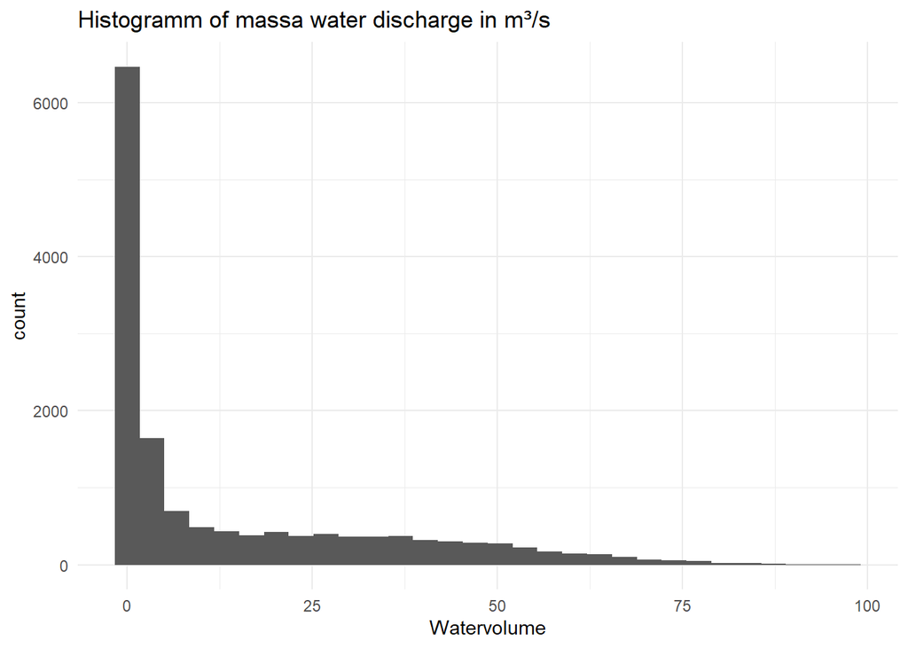

```r
# histogram
p_massa <- ggplot(df_massa_prep, aes(x=Watervolume)) +
  geom_histogram() +
  ggtitle("Histogramm of massa water discharge in m³/s") +
  theme_minimal()
plot(p_massa)
```

#### 5.3.1.2 Plotting lm-trend line

By plotting the trend line of the Massa River discharge over the observed period, we can observe a positive trend. When constructing a trend line based only on the upper 95 quantile values, we obtain a very similar trend, differing only in its offset/intercept.

This indicates that the extreme values follow the same long-term trend as the overall data. For Extreme Value Theory (EVT) analysis, this is important because it suggests that the data can be treated as approximately stationary once the trend is accounted for. If the trends differed significantly, it would be necessary to remove the trend from the extreme values before applying EVT to ensure valid modeling of the extremes.

**EVT Massa Data Preparation**

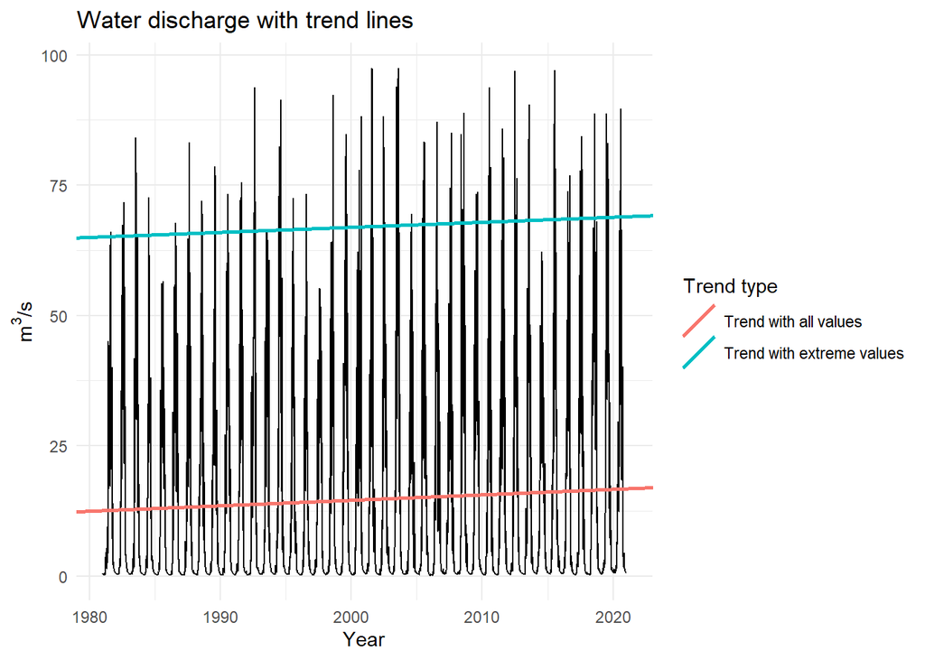

```r
# defining trend lm
massa_t_lm <- lm(Watervolume ~ Date, data = df_massa_prep)

# defining trend lm with extrem values
threshold <- quantile(df_massa_prep$Watervolume, 0.95)  # upper 5%-quantile
massa_ex <- subset(df_massa_prep, Watervolume > threshold)

massa_ex_t_lm <- lm(Watervolume ~ Date, data = massa_ex)

# storing lm coef in dataframe
trend_df <- data.frame(
  intercept = c(coef(massa_t_lm)[1], coef(massa_ex_t_lm)[1]),
  slope     = c(coef(massa_t_lm)[2], coef(massa_ex_t_lm)[2]),
  type      = c("Trend with all values", "Trend with extreme values")
)

# Plotting raw data with trend lines
ggplot(df_massa_prep, aes(x = Date, y = Watervolume)) +
  geom_line(color = "black") +
  geom_abline(data = trend_df,
              aes(intercept = intercept, slope = slope, color = type),
              size = 1) +
  labs(title = "Water discharge with trend lines",
       x = "Year", y = expression("m"^3*"/s"),
       color = "Trend type") +
  theme_minimal()
```

#### 5.3.1.3 EVT Peaks over Threshold (POT)

The return level plot illustrates and predicts the frequency of extreme events. It also shows that the observed values follow the fitted trend line closely. Since the POT method was applied, the return period is expressed on a daily logistic basis.

The return level plot further suggests that approximately every 1,000 days an extreme event of around 100 m³/s may occur. The curve exhibits a logarithmic-like shape, gradually flattening at a level close to 100 m³/s.

**EVT POT massa**

```r
#EVT original data on upper quantil
threshold_massa_evt <- quantile(df_massa_prep$Watervolume, 0.998)
#Amount of observation points
sum(df_massa_prep$Watervolume > threshold_massa_evt)
```

```
## [1] 30
```

```r
massa_ex <- df_massa_prep %>% filter(df_massa_prep$Watervolume > threshold_massa_evt)
massa_ex_fit <- gev.fit(massa_ex$Watervolume)
```

```
## $conv
## [1] 0
##
## $nllh
## [1] 82.74136
##
## $mle
## [1] 89.8943680  3.8270549 -0.3158407
##
## $se
## [1] 0.9164657 0.7789853 0.2838670
```

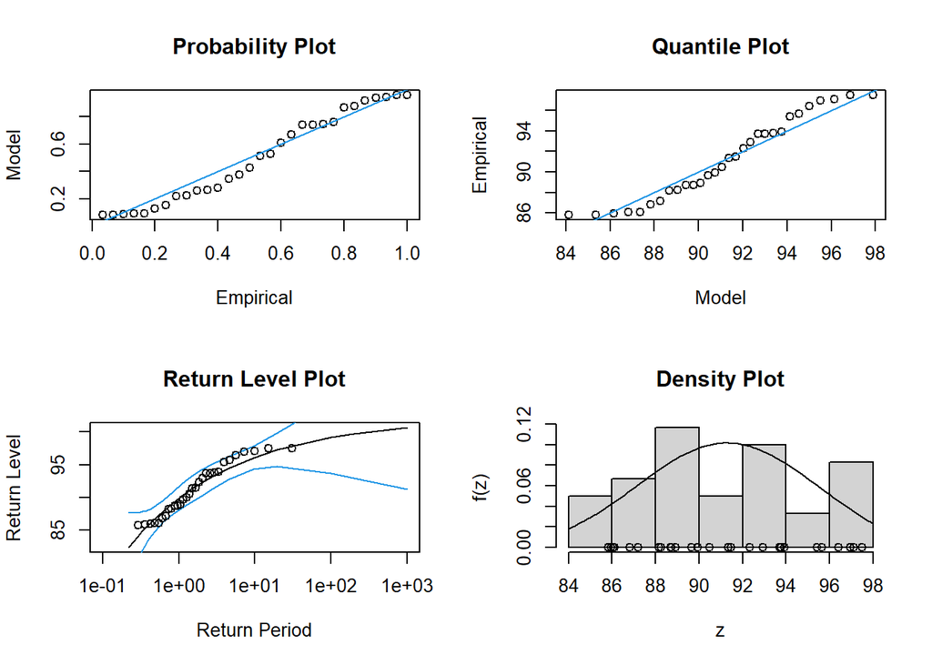

```r
gev.diag(massa_ex_fit) # -> Return Period is on a daily scale
```

```r
massa_ex_fit$mle
```

```
## [1] 89.8943680  3.8270549 -0.3158407
```

#### 5.3.1.4 EVT Block Max Year

With the Block Maxima (yearly) method, we consider the maximum water discharge value of each year. When plotted, the resulting quantile plot shows that the observations align closely with the reference line.

The return level plot illustrates and predicts the frequency of extreme events on a yearly scale. Its shape closely resembles that of the POT approach. After approximately 10 years, the curve approaches a value of around 95 m³/s and levels off into a plateau at approximately 100 m³/s, without exceeding it. This suggests that even over a 1,000-year return period, the discharge is unlikely to surpass 100 m³/s.

**EVT Block max year massa**

```r
#-----------------
#EVT original data block max year

df_massa_prep <- df_massa_prep %>%
  mutate(Date = massa_start_date + (Date - min(Date)))  # Time as day offset

massa_max_year <- df_massa_prep %>%
  mutate(YEAR = year(Date),
         MONTH = month(Date)) %>%
  group_by(YEAR) %>%
  summarize(Watervolume_MAX = max(Watervolume, na.rm = TRUE)) %>%
  ungroup()

massa_max_year_fit <- gev.fit(massa_max_year$Watervolume_MAX)
```

```
## $conv
## [1] 0
##
## $nllh
## [1] 150.4242
##
## $mle
## [1] 79.2855267 12.8319104 -0.6604182
##
## $se
## [1] 2.2701431 2.0178664 0.1562889
```

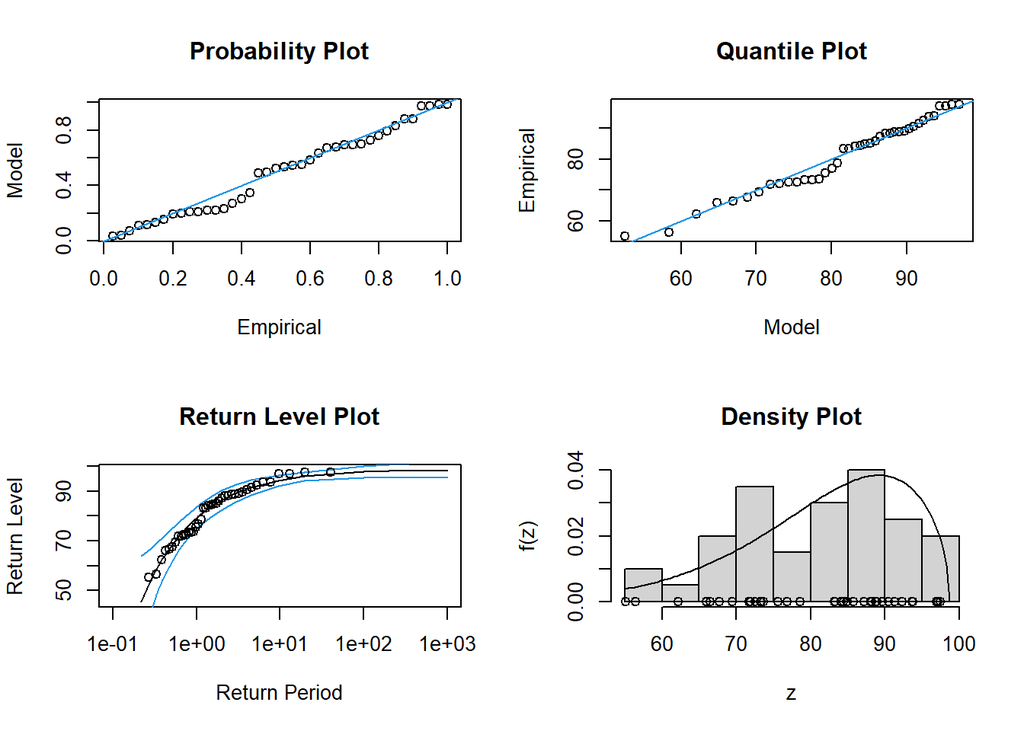

```r
gev.diag(massa_max_year_fit) # -> Return Period is on a yearly scale
```

```r
massa_max_year_fit$mle
```

```
## [1] 79.2855267 12.8319104 -0.6604182
```

#### 5.3.1.5 EVT HQ Values

The ‘EVT HQ Block Max Massa’ table provides a clear and easily interpretable overview of the extreme values. It lists the return periods in years and the corresponding HQ values (High-Flood Discharge, Hochwasserkennwert) in m³/s. It corresponds to the Return Level Plot of the Block Max approach.

**EVT HQ block max Massa**

```r
# Outputting HQ Values
# -> -> Hochwasser-Quantil / Hochwasserabluss: flood quantil for a defined return interval
# -> HQ2 means the watervolume will be achieved/exceeded each 2 years

loc_massa <- massa_max_year_fit$mle[1]
scale_massa <- massa_max_year_fit$mle[2]
shape_massa <- massa_max_year_fit$mle[3]

# return periode in years
return_periods_massa <- c(2, 10, 30, 100, 300)

# probability p = 1 - 1/T
p <- 1 - 1 / return_periods_massa


# calculating HQ-Value
HQ_massa <- qgev(p, loc=loc_massa, scale=scale_massa, shape=shape_massa)

# output
hq_table_massa <- data.frame(ReturnPeriod = return_periods_massa, HQ = HQ_massa)
hq_table_massa
```

```
##   ReturnPeriod       HQ
## 1            2 83.46267
## 2           10 94.31977
## 3           30 96.63675
## 4          100 97.78423
## 5          300 98.26571
```

#### 5.3.1.6 EVT conclusion

Our EVT analysis for the Massa River does not predict any extreme events approaching the “Bemessungshochwasser” of the Gibidum Dam. This indicates that the dam was appropriately dimensioned at the time of its construction and is capable of withstanding future extreme water discharges.

However, as expected, our results differ from the BAG report, which predicts events of up to 150 m³/s (depending on the EVT method used) occurring approximately every 300 years. This difference is primarily due to the BAG analysis being based on daily maximum values, whereas our study uses daily mean values. Consequently, their approach is better suited for capturing the absolute extreme events. Nevertheless, even their estimated extremes remain well below the 450 m³/s design discharge that the Gibidum Dam was engineered to withstand.

What is not addressed in our EVT analysis, however, is the impact of the glacier’s retreat and its associated counterpressure on the valley and surrounding rocks. This may destabilize the ground and trigger landslides, potentially affecting the structural integrity of the dam directly, or indirectly through debris avalanches. Events such as the glacier/rock collapse in Blatten in spring 2025 illustrate how these processes can lead to unpredictable natural disasters.

# 6 Conclusion

This report examined how climate change is reshaping the Aletsch Glacier and the Massa River that supports the town of Brig. By combining historical climate data, statistical forecasting, and extreme value theory, the analysis provides insights into future glaicer melt, water availability and flood risk.

The results show that temperature is a main driver of glacier loss. Glacier mass balance responds to the previous year’s temperature, suggesting a one-year “climate memory.” The ARIMAX model shows a negative association between lagged temperature and glacier mass balance, meaning warmer years tend to coincide with lower glacier mass, after accounting for autocorrelated fluctuations in the series. Precipitation, as measured in the valley, has little effect.

Extreme Value Theory indicates that, despite higher short-term flows, extreme discharges remain below the design limits of the Gibidum Dam. This means major flood risks are unlikely for Brig in the near future. The long-term retreat of the glacier, however, will reduce water storage and may destabilize surrounding slopes, increasing the risk of landslides or debris flows. For Brig and the Canton of Valais, this creates a dual challenge: managing higher seasonal flows now while preparing for eventual water scarcity as the glacier continues to shrink.

The forecasting framework developed in this report offers guidance for early-warning systems, hydropower planning, and adaptive land-use strategies. These findings strengthen the relevance of the UN Sustainable Development Goals by linking local glacier change to global climate action, clean energy, and sustainable water management. Climate adaptation is no longer a vague future goal but an urgent planning priority, requiring continued data collection, open stakeholder dialogue, and regular updates to forecasts to protect both people and alpine ecosystems.

# 7 Outlook and Limitations

Several limitations affect the interpretation and scope of this study, but they also highlight opportunities for future research:

- *Temporal scale mismatch:* we used separate models to forecast annual glacier changes and monthly river flow, instead of one combined system. This prevents us from directly linking glacier melt to river discharge and limits quantification of the effect of glacier retreat on water supply. Future work should adopt integrated glacier–hydrology models.
- *Spatial representativeness:* climate data from Jungfraujoch and Brig may not reflect the full range of glacier conditions. To improve coverage it would be beneficial to include data from additional weather stations and to take into account gridded climate data for further spatial analysis.
- *Model assumptions:* ARIMAX assumes linear climate–glacier relationships, while glacier processes are complex and non-linear. Combining statistical and process-based models would better capture feedbacks, thresholds, and ice dynamics.
- *Forecasting uncertainty:* our forecast for glacier melt is based on three different temperature scenarios, which account for part of the uncertainty in climate conditions. Yet they assume that past climate-glacier relationships will hold under extreme warming. Future research should continue to use multiple scenarios, expand uncertainty ranges and regularly update forecasts.
- *Data gaps:* the current analysis would be greatly enhanced by data from the Massa hydro power project. This would help us identify how much artificial regulation of the Massa water levels is performed by the dam. Using this, we can extrapolate the true effect of the melting ice from the glacier on the river.
- *Additional climate drivers:* the project would benefit by extending the analysis to include other contributing factors such as solar radiation, greenhouse gas emissions and local topography such as slope and ascent. All these factors directly affect glacier melt rate thereby adding to rising water levels in the rivers.
- *Long-term perspective:* considering a long-term plan, including research from other climate studies would be crucial in improving model accuracy by provide more context on global warming trends, comparative data and analyzing general patterns of how glacier melts affect rivers.
- *Regional expansion:* for a future course of action, the analysis can be extended to other glaciers in Switzerland, and even further to the Alps as a whole. Owing to the large size and surface area of Aletsch glacier, it is more resilient to changing environmental conditions. Hence, studying other glaciers might show evidence of more pressing concerns.

# 8 Disclaimer for AI

In the preparation of this report, artificial intelligence (AI) tools were employed to support specific tasks. The following points outline the scope and manner of AI usage:

- reformulation of text passages
- support in R coding for data preparation, visualization and modeling

The responsibility for the selection, verification, and interpretation of all information and results lies entirely with the authors.

# 9 Appendix

## 9.1 Feature Explanation of the dataset

Back to Chapter ‘Datapreparation/Cleaning’

### 9.1.1 Glacier Data

Winter/Summer/Annual mass balance (Bw/Bs/Ba) → millimeters water equivalent (mm w.e.), representing the amount of snow accumulated in winter/summer/annually converted to the equivalent depth of water. The Equilibrium Line Altitude (ELA) -> the elevation on a glacier where annual accumulation equals annual ablation. (If temperatures rise or snowfall decreases, the ELA rises.) Minimum and maximum elevation of glacier → Determines vertical gradient and exposure to temperature changes. Accumulation Area Ratio -> Area of Accumulation Zone / Total Glacier Area. It is used as a climate/glacier health indicator. If the AAR is lower (e.g. 0.2), it means the glacier is losing mass and shrinking.

### 9.1.2 Massa and River Rhone

- waterlevel_m: observed daily water head above sea level in meters
- discharge_vol_m3s: observed catchment discharge m3/s
- discharge_specific_mm: observed catchment-specific discharge (converted to millimetres per day using catchment areas)
- precipitation_mm: observed daily summed precipitation in mm/d
- temp_min: observed daily minimum temperature in Celsius
- temp_mean: observed daily averaged temperature in Celsius
- temp_max: observed daily maximum temperature in Celsius
- rel_sunshine-duration: observed daily averaged relative sunshine (solar irradiance ≥ 200 W m−2) duration in %
- snow_water_equiv_mm: observed daily averaged snow water equivalent in mm (=it is the height of water that would result if you melted the snow down to its liquid state) Meaning of catchment = a land area, bounded by natural high points like hills or mountains, where all water, including rainfall and snowmelt, collects and drains into a single common outlet, such as a river, lake, or the ocean.

## 9.2 EVT river Rhone

Back to Chapter ‘Extreme Value Theory (EVT)’

### 9.2.1 First data analysis rhone

**EVT Rhone Data Preparation**

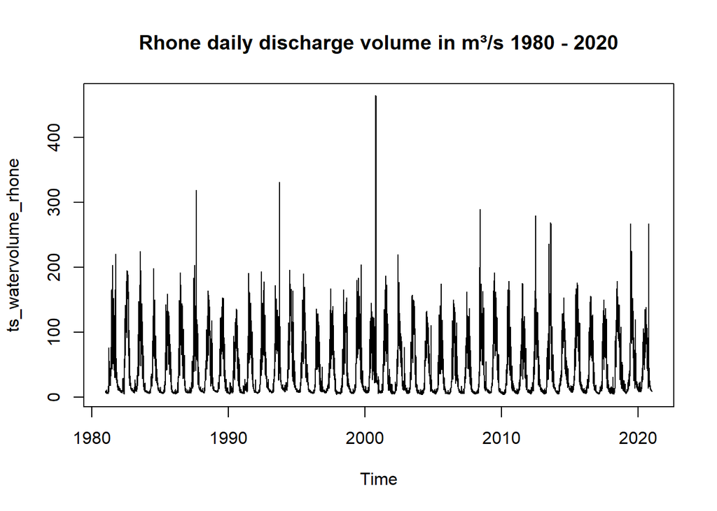

**EVT Rhone Histogram**

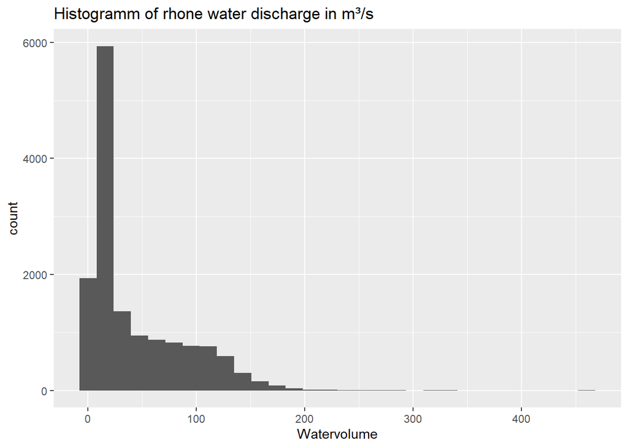

```r
# histogram
p_rhone <- ggplot(df_rhone_prep, aes(x=Watervolume)) +
  geom_histogram() +
  ggtitle("Histogramm of rhone water discharge in m³/s")
plot(p_rhone)
```

### 9.2.2 Plotting lm-trend line

**EVT Rhone Data Preparation**

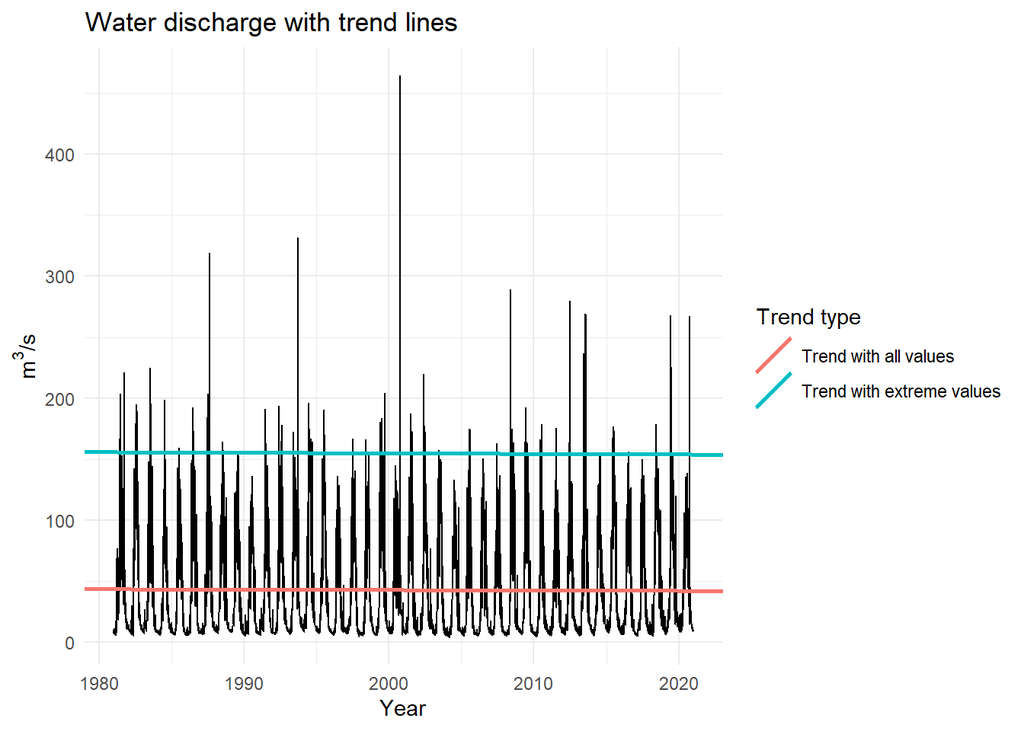

```r
# defining trend lm
rhone_t_lm <- lm(Watervolume ~ Date, data = df_rhone_prep)

# defining trend lm with extrem values
threshold <- quantile(df_rhone_prep$Watervolume, 0.95)  # upper 5%-quantile
rhone_ex <- subset(df_rhone_prep, Watervolume > threshold)

rhone_ex_t_lm <- lm(Watervolume ~ Date, data = rhone_ex)

# storing lm coef in dataframe
trend_df <- data.frame(
  intercept = c(coef(rhone_t_lm)[1], coef(rhone_ex_t_lm)[1]),
  slope     = c(coef(rhone_t_lm)[2], coef(rhone_ex_t_lm)[2]),
  type      = c("Trend with all values", "Trend with extreme values")
)

# Plotting raw data with trend lines
ggplot(df_rhone_prep, aes(x = Date, y = Watervolume)) +
  geom_line(color = "black") +
  geom_abline(data = trend_df,
              aes(intercept = intercept, slope = slope, color = type),
              size = 1) +
  labs(title = "Water discharge with trend lines",
       x = "Year", y = expression("m"^3*"/s"),
       color = "Trend type") +
  theme_minimal()
```

### 9.2.3 EVT Peaks over Threshold (POT)

**EVT POT Rhone**

```r
#EVT original data on upper quantil
threshold_rhone_evt <- quantile(df_rhone_prep$Watervolume, 0.998)
rhone_ex <- df_rhone_prep %>% filter(df_rhone_prep$Watervolume > threshold_rhone_evt)
rhone_ex_fit <- gev.fit(rhone_ex$Watervolume)
```

```
## $conv
## [1] 0
##
## $nllh
## [1] 146.4905
##
## $mle
## [1] 221.6543210  19.3182209   0.6321209
##
## $se
## [1] 4.4338659 4.5308392 0.2657747
```

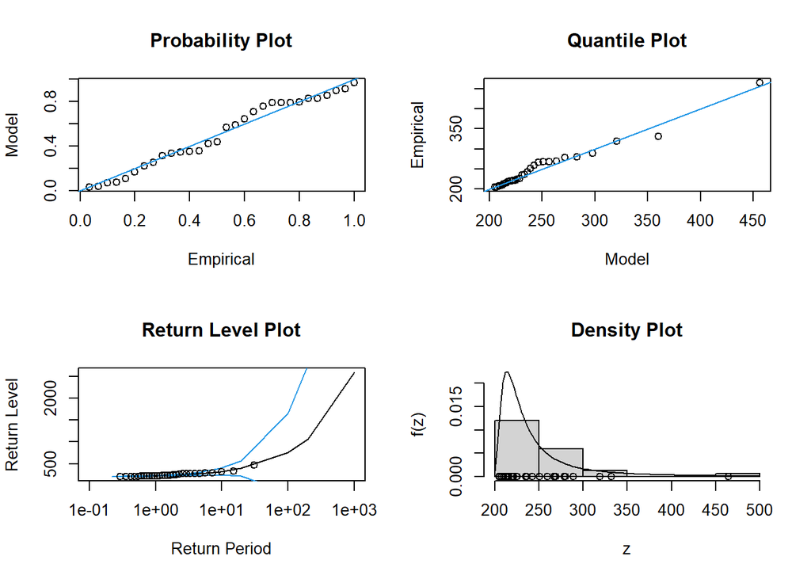

```r
gev.diag(rhone_ex_fit) # -> Return Period is on a daily scale
```

```r
rhone_ex_fit$mle
```

```
## [1] 221.6543210  19.3182209   0.6321209
```

### 9.2.4 EVT Block Max Year

**EVT Block max year Rhone**

```r
#-----------------
#EVT original data block max year

df_rhone_prep <- df_rhone_prep %>%
  mutate(Date = rhone_start_date + (Date - min(Date)))  # Time as day offset

rhone_max_year <- df_rhone_prep %>%
  mutate(YEAR = year(Date),
         MONTH = month(Date)) %>%
  group_by(YEAR) %>%
  summarize(Watervolume_MAX = max(Watervolume, na.rm = TRUE)) %>%
  ungroup()

rhone_max_year_fit <- gev.fit(rhone_max_year$Watervolume_MAX)
```

```
## $conv
## [1] 0
##
## $nllh
## [1] 209.8422
##
## $mle
## [1] 171.5706303  32.9583587   0.3004331
##
## $se
## [1] 5.9830147 5.0490944 0.1458865
```

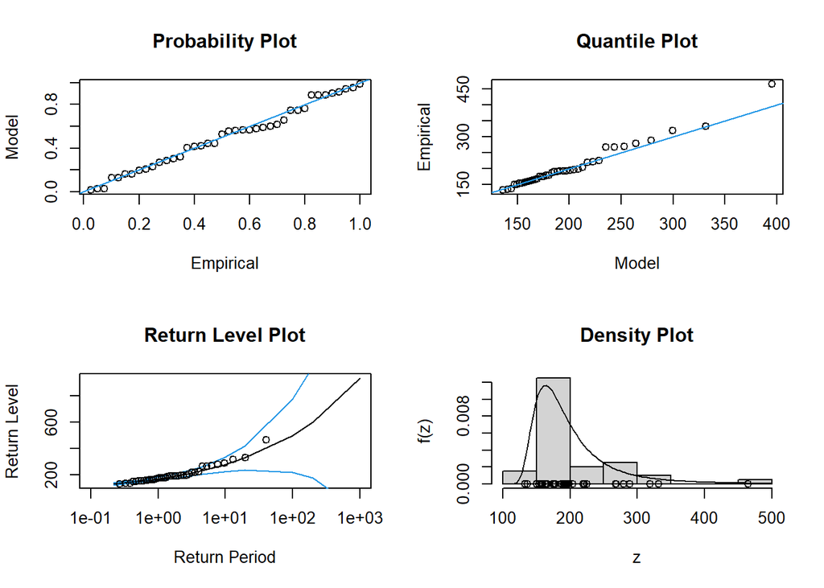

```r
gev.diag(rhone_max_year_fit) # -> Return Period is on a yearly scale
```

```r
rhone_max_year_fit$mle
```

```
## [1] 171.5706303  32.9583587   0.3004331
```

### 9.2.5 EVT HQ Values

**EVT HQ block max Rhone**

```r
# Outputting HQ Values
# -> -> Hochwasser-Quantil / Hochwasserabluss: flood quantil for a defined return interval
# -> HQ2 means the watervolume will be achieved/exceeded each 2 years

loc_rhone <- rhone_max_year_fit$mle[1]
scale_rhone <- rhone_max_year_fit$mle[2]
shape_rhone <- rhone_max_year_fit$mle[3]

# return periode in years
return_periods_rhone <- c(2, 10, 30, 100, 300)

# probability p = 1 - 1/T
p <- 1 - 1 / return_periods_rhone


# calculating HQ-Value
HQ_rhone <- qgev(p, loc=loc_rhone, scale=scale_rhone, shape=shape_rhone)

# output
hq_table_rhone <- data.frame(ReturnPeriod = return_periods_rhone, HQ = HQ_rhone)
hq_table_rhone
```

```
##   ReturnPeriod       HQ
## 1            2 184.3405
## 2           10 277.5616
## 3           30 365.1092
## 4          100 498.8150
## 5          300 670.2960
```